# Figures in KURAMOCHI manuscript

#### source data table and statistic table

```r
rm(list = setdiff(ls(), c("output_dir", "red", "blue", "brown", "green", "purple", "red2", "blue2", "brown2", "green2","red2", "blue3", "hrd_color", "hrp_color", "hrd_vector_color")))
sub_output_dir <- paste0(output_dir, "Figure1/")
if (!dir.exists(sub_output_dir)) {
  dir.create(sub_output_dir)
}
```

```r
sister_d <- readRDS("../data/input/sister_distance.RDS")
```

```r
test <- t.test(sister_d$distance$similarity[sister_d$distance$group == "sisters"], sister_d$distance$similarity[sister_d$distance$group == "non-sisters"])

stat <- sister_d$distance %>%
  group_by(group) %>%
  summarise(mean = mean(similarity, na.rm = TRUE),
            sd = sd(similarity, na.rm = TRUE),
            n = n()) %>%
  mutate(se = sd / sqrt(n),
         lower.ci = mean - qt(1 - (0.05 / 2), n - 1) * se,
         upper.ci = mean + qt(1 - (0.05 / 2), n - 1) * se)
save(test, stat, file = paste0(sub_output_dir, "sister_distances_stat_test.RData"))
```

```r
sister_d2 <- sister_d$distance %>%
  group_by(group) %>%
  mutate(row = row_number()) %>%
  tidyr::pivot_wider(names_from = group, values_from = similarity) %>%
  select(-row)
```

```r
save(sister_d2, file = paste0(sub_output_dir, "sister_distances_plot_table.RData"))
```

## D: UMAP for sister pairs

```r
rm(list = setdiff(ls(), c("output_dir", "red", "blue", "brown", "green", "purple", "red2", "blue2", "brown2", "green2","red2", "blue3", "hrd_color", "hrp_color", "hrd_vector_color")))
sub_output_dir <- paste0(output_dir, "Figure1/")
if (!dir.exists(sub_output_dir)) {
  dir.create(sub_output_dir)
}
```

Load data

```r
merge <- readRDS("../data/input/all_bt_sample_merge_filtered_gene_sisters.RDS")
```

Prepare plot table

```r
all_sister_pairs <- merge$sisters_sample[!endsWith(merge$sisters_sample, "NA")]
all_sister_pairs <- unique(all_sister_pairs)
set.seed(123)
n <- 10
groups <- sample(all_sister_pairs, n)
highlight_group <- vector("list", length(groups))
names(highlight_group) <- groups
for (i in groups){
  highlight_group[[i]] <- colnames(merge)[which(merge$sisters_sample == i)]
}

myCol <- ggsci::pal_npg("nrc")(n)
names(myCol) <- groups
plot_table <- as.data.frame(merge@reductions$umap@cell.embeddings)
plot_table$sisters <- merge$sisters_sample
plot_table$sisters[!plot_table$sisters %in% groups] <- NA
```

UMAP plot

```r
umap <- ggplot(data = plot_table, mapping = aes(x = UMAP_1, y = UMAP_2)) +
  geom_point(
    data = plot_table,
    mapping = aes(x = UMAP_1, y = UMAP_2),
    color = "grey90") +
  geom_point(
    data = plot_table %>% filter(!is.na(sisters)),
    size = 6,
    mapping = aes(x = UMAP_1, y = UMAP_2, color=sisters)
  ) +
  scale_color_manual(values = myCol, labels = seq(1, length(myCol))) +
  geom_line(
    data = plot_table %>% filter(!is.na(sisters)),
    mapping = aes(color = sisters),
    size = 2
  ) +
  labs(
    x = "UMAP 1",
    y = "UMAP 2",
    color = "Lineage label"
  ) +
  theme_classic() +
  theme(
    axis.text = element_text(size = 21, colour = "black"),
    axis.title = element_text(size = 21),
    legend.text = element_text(size = 15),
    legend.title = element_text(size = 18)
  )
umap
ggsave(paste0(sub_output_dir, "/Figure1B3_highlight_sister_group_",paste0(groups, collapse = "."), "_filtered_sisters_umap.pdf"), plot = umap, device = "pdf", width = 6, height = 4)
```

## E: Scatter plot for sister-concordant genes

The calculation of sister-concordant genes were performed on the CSC Puhti server with a batch job. The codes are in: “./codes_for_batch_job/calculate_conserve_gene.R” and “./codes_for_batch_job/calculate_conserve_gene.sh”.

The output files from this batch job are saved in “../data/input/sister_concordant_gene/”

```r
rm(list = setdiff(ls(), c("output_dir", "red", "blue", "brown", "green", "purple", "red2", "blue2", "brown2", "green2","red2", "blue3", "hrd_color", "hrp_color", "hrd_vector_color")))
sub_output_dir <- paste0(output_dir, "Figure1/")
if (!dir.exists(sub_output_dir)) {
  dir.create(sub_output_dir)
}
```

Load data

```r
conserve_gene <- read.csv(
  "../data/input/sister_concordant_gene/sister_conserve_gene_all_bt_sample_twin.csv",
  stringsAsFactors = FALSE)
```

Prepare data table for plot

```r
highlight_gene_symbols <- conserve_gene %>%
  arrange(desc(log2FC_dif)) %>%
  head(10) %>%
  select(symbol) %>%
  unlist()
data_plot <- conserve_gene %>%
  mutate(log10_p_value = -log10(adj_p_value)) %>%
  mutate(
    highlight = ifelse(
      log10_p_value > -log10(0.05),
      "sister-concordant gene",
      "sister-disconcordant gene"
    ),
    label = (
      symbol %in% highlight_gene_symbols
    )
  )
data_plot$highlight <- factor(data_plot$highlight, levels = c("sister-concordant gene", "sister-disconcordant gene"))
cor <- cor.test(data_plot$mean_log2FC_sister, data_plot$mean_log2FC_non_sister)

write_xlsx(data_plot, paste0(sub_output_dir, "Figure1E_conserve_gene_logFC_p_plot_table.xlsx"))
save(cor, file = paste0(sub_output_dir, "Figure1E_conserve_gene_logFC_p_stat_test.RData"))
```

Visualization

```r
p <-
  ggplot(
    data_plot,
    aes(
      x = mean_log2FC_sister,
      y = mean_log2FC_non_sister,
      color = highlight
    )
  ) +
  geom_point() +
  lims(x = c(0, 1.5), y = c(0, 1.5)) +
  scale_color_manual(values = c("#E64B3555", "#3C5488")) +
  geom_abline(slope = 1, intercept = 0, linetype = "dashed") +
  annotate(
    geom = "text",
    x = 1.0,
    y = 0.2,
    label = paste0("R = ", signif(cor$estimate, 2), "\n", ifelse(cor$p.value == 0, "P < 2.2E-16", paste0("P =", format(cor$p.value, scientific = T)))),
    size = 15/.pt
  ) +
  geom_point(
    data=dplyr::filter(data_plot, label==TRUE),
    size = 3,
    color = "#DC0000") +
  geom_point(
    data=dplyr::filter(data_plot, label==TRUE),
    shape = 1,
    size = 3,
    show.legend = FALSE,
    color = "black"
  ) +
  ggrepel::geom_text_repel(
    data=dplyr::filter(
      data_plot, label==TRUE),
    aes(label = symbol),
    box.padding = 0.5,
    colour="black", point.padding = 0.25, max.overlaps = 30,
    size = 15/.pt,
    fontface="bold",
    show.legend=FALSE) +
  labs(
       x = expression("Sister cell pair log"[2]~"(FC)"),
       y = expression("Random cell pair log"[2]~"(FC)")
       ) +
  theme_classic() +
  theme(legend.position="right",
        axis.ticks.x = element_blank(),
        axis.text = element_text(size = 21, color = "black"),
        text = element_text(size = 22.5, color = "black"),
        axis.title = element_text(size = 21, color = "black")
      ) +
  guides(colour = "none")
p
ggsave(paste0(sub_output_dir, "Figure1E_conserve_gene_adjust_p.pdf"), p,
       width = 4, height = 4)
```

## F: RNA dynamics from RNA velocity analysis

The alignment is done with velocyto. The codes are in: “./codes_for_batch_job/runVelo.sh”

The scVelo is used to do the RNA velocity analysis. The codes are in “./codes_for_batch_job/runscvelo.py” and “./codes_for_batch_job/runscvelo.sh”

The outputs are saved in “../data/input/scvelo/”

```r
rm(list = setdiff(ls(), c("output_dir", "red", "blue", "brown", "green", "purple", "red2", "blue2", "brown2", "green2","red2", "blue3", "hrd_color", "hrp_color", "hrd_vector_color")))
sub_output_dir <- paste0(output_dir, "Figure1/")
if (!dir.exists(sub_output_dir)) {
  dir.create(sub_output_dir)
}
```

Load data

```r
dynamic <- read.csv("../data/input/scvelo/RNA_velocity_var_all_BT.csv")
# conserve_gene <- read.csv("../data/input/sister_concordant_gene/sister_conserve_gene_all_bt_sample_twin.csv")
selected_genes <- read.csv("../data/input/sister_concordant_gene/sum_exp_sister_conserve_gene_second_bin.csv")
```

Prepare table for plot

```r
plot_table <- selected_genes %>%
  mutate(conserve_gene = ifelse(Sister.conserved.gene, "Sister-concordant", "Sister-discordant")) %>%
  right_join(dynamic, by = c("ensembl" = "X")) %>%
  select(
    ensembl,
    transcription = fit_alpha,
    splicing = fit_beta,
    degradation = fit_gamma,
    conserve_gene) %>%
  na.omit()
plot_table$conserve_gene <- factor(plot_table$conserve_gene, levels = c("Sister-concordant", "Sister-discordant"))
t <- plot_table %>%
  select(ensembl, transcription, value = splicing, conserve_gene) %>%
  mutate(dynamic = "splicing") %>%
  rbind.data.frame(
    plot_table %>%
      select(ensembl, transcription, value = degradation, conserve_gene) %>%
      mutate(dynamic = "degradation"))
t$dynamic <- str_to_title(t$dynamic)
t$dynamic <- factor(t$dynamic, levels = c("Splicing", "Degradation"))

table(plot_table$conserve_gene)
```

```
Sister-concordant Sister-discordant
              919               107
```

Visualization

```
rsession(78940) MallocStackLogging: can't turn off malloc stack logging because it was not enabled.
```

[figure not shown]

```r
min_value <- min(c(t$transcription, t$value))
max_value <- max(c(t$transcription, t$value))
p <- ggplot(t, aes(x = transcription, y = value)) +
  stat_density_2d(aes(fill = after_stat(ndensity)), geom = "raster", contour = FALSE,
                  ) +
  scale_fill_viridis() +
  labs(x = "Transcription") +
  geom_abline(
    intercept = 0,
    slope = 1,
    color = "#FFFFFFFF",
    linetype = "dashed",
    size = 1) +
  scale_y_continuous(
    expand = c(0, 0),
    limits = c(min_value, max_value),
    trans = log2_trans(),
    breaks = trans_breaks("log2", function(x) 2^x),
    labels = trans_format("log2", math_format(2^.x))) +
  scale_x_continuous(
    expand = c(0, 0),
    limits = c(min_value, max_value),
    trans = log2_trans(),
    breaks = trans_breaks("log2", function(x) 2^x),
    labels = trans_format("log2", math_format(2^.x))) +
  coord_equal(xlim=c(min_value, max_value),ylim=c(min_value, max_value)) +
  facet_grid(vars(dynamic), vars(conserve_gene)) +
  theme(
    legend.position = "none",
    strip.text.x = element_text(
      size = 15
    ),
    strip.text.y = element_text(
      size = 15
    ),
    axis.text = element_text(size = 15, colour = "black"),
    axis.title.y = element_blank(),
    axis.title.x = element_text(
      size = 21, face = "plain"
    )
  )
p
ggsave(
  paste0(
    sub_output_dir,
    "Figure1D_sister_conserve_gene_dynamic_log_scale_second_bin.pdf"
  ),
  p, width = 4.5, height = 4.5
)
```

```r
# Source data table
write_xlsx(t, paste0(
    sub_output_dir,
    "Figure1F_sister_conserve_gene_dynamic_log_scale_second_bin_plot_table.xlsx"
  ))
```

## G: Gene set analysis for sister-discordant genes

1. We calculated the summation of all of the gene’s expression across all of the cells in all BT samples. (results in ‘../data/input/sister_concordant_gene/sum_exp_sister_conserve_gene_all_bt_sample_twin.csv’)
2. We generated a histogram for the summation of expression for all of the genes (see below Figure S2A). Genes are grouped by sister-concordant genes (adj_p_value < 0.05 and log2FC_diff > 0) or sister-discordant genes (adj_p_value > 0.05 or log2FC_diff < 0).
3. The genes in the second bin (second bar for each group) in the histogram are extracted and the gene set enrichment analysis is done on each group (sister-concordant genes n = 2059 [enrichr result](https://maayanlab.cloud/Enrichr/enrich?dataset=fe932ded91e8f8298f674699e8b007eb), and non-sister-concordant genes n = 1332 [enrichr result](https://maayanlab.cloud/Enrichr/enrich?dataset=7b522be89fef4b4a4f08355a0ef3703d))
4. The tables for Pathways “KEGG 2021 Human” are downloaded and saved in “../data/input/enrichr/KEGG_2021_Human_table_sister_conserved_gene.txt” and “../data/input/enrichr/KEGG_2021_Human_table_non_conserved_gene.txt”

```r
rm(list = setdiff(ls(), c("output_dir", "red", "blue", "brown", "green", "purple", "red2", "blue2", "brown2", "green2","red2", "blue3", "hrd_color", "hrp_color", "hrd_vector_color")))
sub_output_dir <- paste0(output_dir, "Figure1/")
if (!dir.exists(sub_output_dir)){
  dir.create(sub_output_dir, recursive = TRUE)
}
```

[figure not shown]

# Figure S1: Cell doubling, lineage labelling efficiency, and quality assessment of ReSisTrace

## A: Percentage of cells have barcodes

```r
rm(list = setdiff(ls(), c("output_dir", "red", "blue", "brown", "green", "purple", "red2", "blue2", "brown2", "green2","red2", "blue3", "hrd_color", "hrp_color", "hrd_vector_color")))
sub_output_dir <- paste0(output_dir, "FigureS1/")
if (!dir.exists(sub_output_dir)) {
  dir.create(sub_output_dir)
}
```

Prepare data table

```r
data <- readRDS("../data/input/merged_KURAMOCHI_samples1_scaled_new.RDS")
```

```r
table <- data@meta.data %>%
  mutate(label_detect = !is.na(drugSens)) %>%
  select(sample, time_point, label_detect) %>%
  group_by(sample, time_point, label_detect) %>%
  summarize(n = n(), .groups = "keep")

total <- table %>%
  group_by(sample, time_point) %>%
  summarise(total = sum(n), .groups = "keep")
```

Visualization

```r
plot_table <- table %>%
  left_join(total, by = c("sample", "time_point")) %>%
  mutate(proportion = n/total * 100)
plot_table <- plot_table %>%
  mutate(
    sample = case_when(
      sample == "Carbo1" ~ "Carboplatin 1",
      sample == "Carbo2" ~ "Carboplatin 2",
      sample == "ctrl1" ~ "Control 1",
      sample == "ctrl2" ~ "Control 2",
      sample == "Olaparib1" ~ "Olaparib 1",
      sample == "Olaparib2" ~ "Olaparib 2",
      sample == "NK1" ~ "NK 1",
      sample == "NK2" ~ "NK 2"
    ),
    time_point = case_when(
      time_point == "AfterTreatment" ~ "Post-treatment",
      time_point == "BeforeTreatment" ~ "Pre-treatment"
    ))
plot_table$sample <- factor(
  plot_table$sample,
  levels = c("Carboplatin 1", "Carboplatin 2", "Olaparib 1", "Olaparib 2",
             "NK 1", "NK 2", "Control 1", "Control 2")
  )
write.csv(plot_table, paste0(sub_output_dir, "FigureS1A_proportion_of_cells_having_label_plot_table.csv"), row.names = FALSE)


colors = c("#8f9dbb","#d1d7e3")

p <- ggplot(
  plot_table %>% filter(time_point == "Pre-treatment"),
  aes(x = sample, y = proportion, fill = label_detect)
  ) +
  geom_bar(position = "stack", stat = "identity") +
  labs(
    y = "Proportion of cells (%)",
    fill = "Lineage labels detected",
    title = "Pre-treatment"
  ) +
  ylim(c(0, 100)) +
  scale_fill_manual(values = colors) +
  theme_classic() +
  theme(
    text = element_text(size = 20),
    axis.text.x = element_text(
      angle = 45,
      hjust = 1,
      size = 20,
      color = "black"
    ),
    axis.text.y = element_text(
      size = 20,
      color = "black"
    ),
    axis.title.x = element_blank(),
    legend.text = element_text(size = 15),
    legend.title = element_text(size = 20),
    plot.title = element_text(size = 20, hjust = 0.5),
    panel.grid = element_blank()
  )
ggsave(paste0(sub_output_dir, "FigureS1A_proportion_of_cells_having_label_preTreatment.pdf"), width = 8, height = 5.3)

p <- ggplot(
  plot_table %>% filter(time_point == "Post-treatment"),
  aes(x = sample, y = proportion, fill = label_detect)
  ) +
  geom_bar(position = "stack", stat = "identity") +
  labs(
    y = "Proportion of cells (%)",
    fill = "Lineage labels detected",
    title = "Post-treatment"
  ) +
  ylim(c(0, 100)) +
  scale_fill_manual(values = colors) +
  theme_classic() +
  theme(
    text = element_text(size = 20),
    axis.text.x = element_text(
      angle = 45,
      hjust = 1,
      size = 20,
      color = "black"
    ),
    axis.text.y = element_text(
      size = 20,
      color = "black"
    ),
    axis.title.x = element_blank(),
    legend.text = element_text(size = 15),
    legend.title = element_text(size = 20),
    plot.title = element_text(size = 20, hjust = 0.5),
    panel.grid = element_blank()
  )
ggsave(paste0(sub_output_dir, "FigureS1A_proportion_of_cells_having_label_postTreatment.pdf"), width = 8, height = 5.3)
```

## B: Number of unique barcode per sample

```r
rm(list = setdiff(ls(), c("output_dir", "red", "blue", "brown", "green", "purple", "red2", "blue2", "brown2", "green2","red2", "blue3", "hrd_color", "hrp_color", "hrd_vector_color")))
sub_output_dir <- paste0(output_dir, "FigureS1/")
if (!dir.exists(sub_output_dir)) {
  dir.create(sub_output_dir)
}
```

Prepare data table

```r
samples <- c("Control_1", "Control_2", "Carboplatin_1", "Carboplatin_2", "Olaparib_1", "Olaparib_2", "NK_1", "NK_2")

label_sequences <- vector(mode = "list", length = length(samples))
names(label_sequences) <- samples

for (s in samples){
  load(paste0("../data/input/preprocess/", s, "/lineage_label_tables.RData"))
  label_id_bt <- sapply(l_b_fre_merge_filtered[["lineage_id"]], function(x)(strsplit(x, ":")))
  label_id_bt <- unique(purrr::reduce(label_id_bt, `c`))
  label_index <- label_index %>%
    filter(seq_id %in% label_id_bt)
  label_index$sample <- s
  label_index$total <- nrow(label_index)
  label_sequences[[s]] <- label_index
}

label_sharing <- bind_rows(label_sequences)
frequency <- as.data.frame(table(label_sharing$seq))
names(frequency) <- c("seq", "freq")
label_sharing <- left_join(label_sharing, frequency, by = "seq")
max(label_sharing$freq)
table(label_sharing$freq)
table(label_sharing$freq)/nrow(label_sharing) * 100
```

```r
# proportion of different frequency in each sample
plot_table <- label_sharing %>%
  mutate(unique = freq == 1) %>%
  group_by(sample, unique) %>%
  summarise(
    n = n(),
    total = mean(total),
    .groups = "keep") %>%
  mutate(
    proportion = n/total * 100
  )
# plot_table$freq <- factor(plot_table$freq, levels = seq(6, 1))
plot_table$sample <- gsub("_", " ", plot_table$sample)
plot_table$sample <- factor(
  plot_table$sample,
  levels = c("Carboplatin 1", "Carboplatin 2", "Olaparib 1", "Olaparib 2",
              "NK 1", "NK 2", "Control 1", "Control 2")
  )
write.csv(plot_table, paste0(sub_output_dir, "FigureS1B_unique_label_per_bt_sample_plot_table.csv"), row.names = FALSE)

colors = c("#8f9dbb","#d1d7e3")

p <- ggplot(plot_table, aes(x = sample, y = proportion, fill = unique)) +
  geom_bar(position = "stack", stat = "identity") +
  labs(
    y = "Proportion of lineage labels (%)",
    fill = ""
  ) +
  # ylim(c(0, 100)) +
  scale_fill_manual(values = colors, labels = c("Shared by samples", "Unique per sample")) +
  theme_classic() +
  theme(
    text = element_text(size = 20),
    axis.text.x = element_text(
      angle = 45,
      hjust = 1,
      size = 20,
      color = "black"
    ),
    axis.text.y = element_text(
      size = 20,
      color = "black"
    ),
    axis.title.x = element_blank(),
    legend.text = element_text(size = 20),
    # legend.title = element_text(size = 15),
    # legend.position = "top",
    panel.grid = element_blank()
  )
ggsave(paste0(sub_output_dir, "FigureS1B_unique_label_per_bt_sample.pdf"), width = 7.5, height = 5)

plot_table %>%
  ungroup() %>%
  filter(unique == TRUE) %>%
  summarise(mean = mean(proportion))
```

## C: Cell cycle proportion

```r
data <- read_xlsx(
  "../data/input/cell cycle analysis.xlsx",
  range = c("B2:D22")) %>%
  na.omit() %>%
  mutate(
    group = rep(c("Control", "Tymidine block", "Unreleased (4h)", "Released (4h)", "Unreleased (8h)", "Released (8h)"), each = 3)) %>%
  pivot_longer(
    cols = -group,
    names_to = "cell_cycle",
    values_to = "proportion"
  )

plot_table <- data %>%
  group_by(group, cell_cycle) %>%
  summarise(
    proportion_mean = mean(proportion),
    proportion_sd = sd(proportion),
    .groups = "keep"
  )
plot_table$cell_cycle <- paste(plot_table$cell_cycle, "phase")
plot_table$cell_cycle <- factor(plot_table$cell_cycle, levels = c("S phase", "G1 phase", "G2/M phase"))
plot_table$group <- factor(plot_table$group, levels = c("Control", "Tymidine block", "Unreleased (4h)", "Released (4h)", "Unreleased (8h)", "Released (8h)"))

# Calculate position for error bar
plot_table <- plot_table %>%
  arrange(group, desc(cell_cycle)) %>%
  mutate(SDPos = cumsum(proportion_mean))

dot_data <- data %>%
  mutate(
    replicate = rep(rep(c(1:3), each = 3), times = 6),
    accumulate_prop = 0
  )

for (i in seq(1, nrow(dot_data) - 2, by = 3)) {
  #G2/M
  dot_data$accumulate_prop[i+2] <- dot_data$proportion[i+2]
  #G1
  dot_data$accumulate_prop[i] <- plot_table$SDPos[plot_table$group == dot_data$group[i] & plot_table$cell_cycle == "G2/M phase"] + dot_data$proportion[i]
  #S
  dot_data$accumulate_prop[i+1] <- plot_table$SDPos[plot_table$group == dot_data$group[i] & plot_table$cell_cycle == "G1 phase"] + dot_data$proportion[i+1]

}

p <- ggplot(plot_table,
    aes(x = group, y = proportion_mean, fill = cell_cycle)
  ) +
  geom_col() +
  labs(
    y = "Cell cycle distribution (%)",
    fill = "",
    x = "") +
  scale_fill_manual(values = c("#3c5488", "#8f9dbb", "#d1d7e3")) +
  geom_point(
    data = dot_data,
    mapping = aes(x = group, y = accumulate_prop),
    color = "grey",
    fill = "grey",
    position = position_jitter(width = 0.4, seed = 1)
  ) +
  geom_errorbar(
    aes(ymin = SDPos - proportion_sd, ymax = SDPos + proportion_sd),
    width = 0.3,
    position = "identity"
  ) +
  theme_classic() +
  theme(
    text = element_text(size = 20),
    axis.text.x = element_text(
      angle = 45,
      hjust = 1,
      size = 20,
      color = "black"
    ),
    axis.text.y = element_text(
      size = 20,
      color = "black"
    ),
    legend.text = element_text(size = 20),
    plot.title = element_text(hjust = 0.5, size = 20),
    panel.grid = element_blank()
  )
ggsave(paste0(sub_output_dir, "FigureS1C_cell_cycle_distribution.pdf"), width = 6, height = 5.7)
```

## F: Number of divisions after 1x doubling

The data table comes from Jun. He manually counted the number of cells which divided zero, once, twice or more times after “1 x doubling time”. Totally 6 views are counted.

```r
rm(list = setdiff(ls(), c("output_dir", "red", "blue", "brown", "green", "purple", "red2", "blue2", "brown2", "green2","red2", "blue3", "hrd_color", "hrp_color", "hrd_vector_color")))
sub_output_dir <- paste0(output_dir, "FigureS1/")
if (!dir.exists(sub_output_dir)) {
  dir.create(sub_output_dir)
}
```

Load data

```r
data <- read_xlsx("../data/input/ReSisTrace_figS1 - Copy.xlsx", range = "B1:G4")
data <- t(data)
colnames(data) <- c("0", "1", "> 1")
data <- data * 100
data <- data %>%
  as.data.frame() %>%
  mutate(view = 1:6) %>%
  pivot_longer(!view, names_to = "Division", values_to = "Proportion")
data$Division <- factor(data$Division, levels = c("0", "1", "> 1"))
```

Prepare table for plot

```r
plot_table <- data %>%
  dplyr::group_by(Division) %>%
  dplyr::summarise(
    mean = mean(Proportion),
    sd = sd(Proportion)
  )
write.csv(plot_table, paste0(sub_output_dir, "FigureS1A_cell_division_times.csv"), row.names = FALSE)
```

```
rsession(85054) MallocStackLogging: can't turn off malloc stack logging because it was not enabled.
```

```r
col = c("#d1d7e3", "#8f9dbb", "#3c5488")
```

```r
p <- ggplot(plot_table, aes(x = Division, y = mean, fill = Division)) +
  geom_bar(
    stat="identity", color="black",
    position=position_dodge()
  ) +
  geom_errorbar(
    aes(ymin = mean - sd, ymax = mean + sd, width = 0.2), color="black"
  ) +
  geom_point(
    data = data,
    mapping = aes(x = Division, y = Proportion),
    position = position_jitterdodge(jitter.width = 2)
  ) +
  scale_fill_manual(values = col) +
  labs(
    x = "Division(s)",
    y = "Proportion of clones (%)"
  ) +
  theme_classic() +
  theme(
    legend.position = "None",
    text = element_text(size = 20, color = "black"),
    axis.text = element_text(size = 20, color = "black")
  )
ggsave(
  paste0(sub_output_dir, "FigureS1F_cell_division_times.pdf"),
  width = 5, height = 4.8
)
```

## G: Counts of lineages in the BT sample

The information about lineage labels for each samples are saved in “../data/input/preprocess/[sample_name]/lineage_label_tables.RData”. After loading the “.RData” files, a data frame “l_b_fre_merge_filtered” will be in the working environment. This table contains the lineage label information for pre-treatment samples from different treatments.

```r
rm(list = setdiff(ls(), c("output_dir", "red", "blue", "brown", "green", "purple", "red2", "blue2", "brown2", "green2","red2", "blue3", "hrd_color", "hrp_color", "hrd_vector_color")))
sub_output_dir <- paste0(output_dir, "FigureS1/")
if (!dir.exists(sub_output_dir)) {
  dir.create(sub_output_dir)
}
```

Prepare table for plot

```r
plot_table <- NULL

samples <- c("Control_1", "Control_2", "Carboplatin_1", "Carboplatin_2", "Olaparib_1", "Olaparib_2", "NK_1", "NK_2")

for (s in samples){
  load(paste0("../data/input/preprocess/", s, "/lineage_label_tables.RData"))
  tmp <- l_b_fre_merge_filtered %>%
    select(lineage_id) %>%
    table() %>%
    table() %>%
    prop.table()
  tmp2 <- l_b_fre_merge_filtered %>%
    select(lineage_id) %>%
    table() %>%
    table()
  cat(s, "\n", tmp2, "\n")
  tmp <- data.frame(
    Size_of_lineage = tmp,
    Sample = s,
    label_at = length(unique(l_a_fre_merge_filtered$lineage_id)),
    label_bt = length(unique(l_b_fre_merge_filtered$lineage_id)),
    label_btat = length(unique(intersect(l_b_fre_merge_filtered$lineage_id, l_a_fre_merge_filtered$lineage_id)))
  )
  plot_table <- rbind.data.frame(plot_table, tmp)
}

colnames(plot_table) <- c("Size_of_lineage", "Frequency", "Sample", "labelAT", "labelBT", "labelBTAT")
write.csv(
  plot_table,
  paste0(sub_output_dir, "FigureS1G_frequence_of_lineage_label.csv"),
  row.names = FALSE
)
```

Visualization

```r
plot_table$Frequency <- plot_table$Frequency * 100
data <- plot_table
plot_table <- plot_table %>%
  dplyr::group_by(Size_of_lineage) %>%
  dplyr::summarise(
    mean = mean(Frequency),
    sd = sd(Frequency)
  )
col = c("#d1d7e3", "#8897b7", "#5e729d", "#3c5488")
p <- ggplot(plot_table, aes(x = Size_of_lineage, y = mean, fill = Size_of_lineage)) +
  geom_bar(
    stat="identity", color="black",
    position=position_dodge()
  ) +
  geom_errorbar(
    aes(ymin = mean - sd, ymax = mean + sd, width = 0.2), color="black"
  ) +
  geom_point(
    data = data,
    aes(x = Size_of_lineage, y = Frequency),
    position = position_jitterdodge(jitter.width = 2)
  )+
  scale_fill_manual(values = col) +
  labs(
    x = "Clone size",
    y = "Proportion of lineages (%)"
  ) +
  theme_classic() +
  theme(
    legend.position = "None",
    text = element_text(size = 20, color = "black"),
    axis.text = element_text(size = 20, color = "black")
  )
ggsave(
  paste0(sub_output_dir, "FigureS1G_frequence_of_lineage_label.pdf"),
  width = 5, height = 4.8
)
```

## H: Computer simulation results

This plot is generated by the codes saved in file “./simulation_program.Rmd”

```r
rm(list = setdiff(ls(), c("output_dir", "red", "blue", "brown", "green", "purple", "red2", "blue2", "brown2", "green2","red2", "blue3", "hrd_color", "hrp_color", "hrd_vector_color")))
sub_output_dir <- paste0(output_dir, "FigureS1/")
if (!dir.exists(sub_output_dir)){
  dir.create(sub_output_dir, recursive = TRUE)
}
```

```r
treatments <- c("Carboplatin", "Olaparib", "NK", "Control")
for (t in treatments){
  t_short <- switch (t,
    "Carboplatin" = "Carbo",
    "Control" = "scLT_ctrl",
    "NK" = "NK",
    "Olaparib" = "Olaparib"
  )
  deg <- read.csv(
    paste0(
      "../data/input/DEG/deg_prer_pres_in_singleton_",
      t,
      "_intersection.csv"
    )
  )

  # Plot table
  write_xlsx(
    select(deg, "ensembl", paste0(t_short, "_1_avg_log2FC"), paste0(t_short, "_2_avg_log2FC")),
    paste0(sub_output_dir, "FigureS1I_correlation_between_replicates_", t, "plot_table.xlsx")
  )

  cat("Number of genes ", nrow(deg), "\n")
  cor <- cor.test(
    deg[[paste0(t_short, "_1_avg_log2FC")]],
    deg[[paste0(t_short, "_2_avg_log2FC")]]
  )
  save(cor, file = paste0(sub_output_dir, "FigureS1I_correlation_between_replicates_", t, "stat_test.RData"))
  range <- range(
    c(
      deg[[paste0(t_short, "_1_avg_log2FC")]],
      deg[[paste0(t_short, "_2_avg_log2FC")]]
    )
  )
  p <- ggplot(
    data = deg,
    aes_string(
      x = paste0(t_short, "_1_avg_log2FC"),
      y = paste0(t_short, "_2_avg_log2FC")
    )
    ) +
    geom_point(
      color = "#3C548855",
      size = 6,
      show.legend = FALSE
    ) +
    ylim(range) +
    xlim(range) +
    geom_abline(slope = 1, intercept = 0, linetype = "dashed") +
    annotate(
      geom = "text",
      x = 0.15,
      y = - 0.3,
      label = paste0(
        "R = ", signif(cor$estimate, 2), "\n",
        ifelse(
          cor$p.value == 0, "P < 2.2E-16",
          paste0("P =", format(cor$p.value, scientific = T))
        )
      ),
      size = 6.5
    ) +
    labs(
      x = expression("Replicate 1 log"[2]~"(FC)"),
      y = expression("Replicate 2 log"[2]~"(FC)"),
      title = t
    ) +
    theme_classic() +
    theme(
      legend.position="none",
      axis.ticks.x = element_blank(),
      axis.text = element_text(size = 21, colour = "black"),
      axis.title = element_text(size = 21, colour = "black"),
      plot.title = element_text(size = 21, hjust = 0.5, colour = "black", face = "bold")
    )
  p
  ggsave(paste0(sub_output_dir, "FigureS1I_correlation_between_replicates_", t, ".pdf"), p,
         width = 5, height = 5)
}
```

```
Number of genes  30613
Number of genes  30586
Number of genes  30613
Number of genes  27478
```

# Figure S2: Characteristics of sister-concordant and sister-discordant genes

## A: Histogram for gene expressions of sister-conserved/non-conserved genes

```r
rm(list = setdiff(ls(), c("output_dir", "red", "blue", "brown", "green", "purple", "red2", "blue2", "brown2", "green2","red2", "blue3", "hrd_color", "hrp_color", "hrd_vector_color")))
sub_output_dir <- paste0(output_dir, "FigureS2/")
if (!dir.exists(sub_output_dir)){
  dir.create(sub_output_dir, recursive = TRUE)
}
```

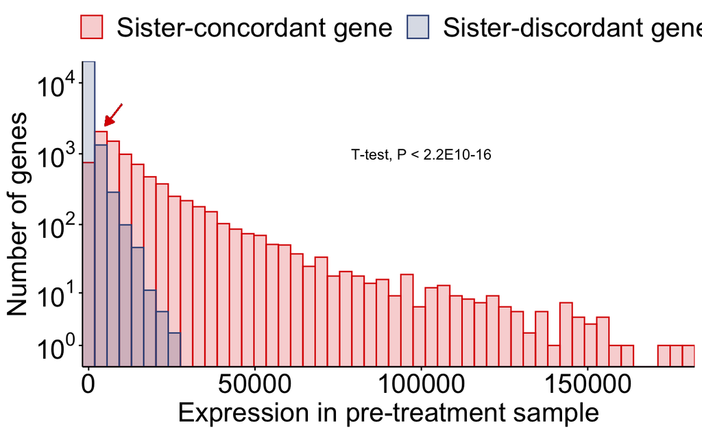

```r
plot_table <- read.csv("../data/input/sister_concordant_gene/sum_exp_sister_conserve_gene_all_bt_sample_twin.csv")
t_test <- t.test(plot_table$mean_expression[plot_table$conserve_gene == TRUE], plot_table$mean_expression[plot_table$conserve_gene == FALSE])
save(t_test, file = paste0(sub_output_dir, "FigureS2A_sister_conserve_gene_exp_distribution_stat_test.RData"))

plot_table <-  plot_table %>%
  mutate(`Sister-conserved gene` = ifelse(conserve_gene, "Sister-concordant gene", "Sister-discordant gene")) %>%
  select(ensembl, `Sister-conserved gene`, sum_expression, mean_expression)

mylog10_trans <- function (base = 10)
{
  trans <- function(x) log(x + 1, base)
  inv <- function(x) base^x
  trans_new(paste0("log-", format(base)), trans, inv, log_breaks(base = base),
            domain = c(1e-100, Inf))
}

p <- ggplot(
  plot_table,
  aes(
    x = sum_expression,
    fill = `Sister-conserved gene`,
    color = `Sister-conserved gene`
    )
  ) +
  geom_histogram(
    alpha=0.2,
    bins = 50,
    position="identity"
  ) +
  scale_fill_manual(values = c("#DC000055", "#3C548855")) +
  scale_color_manual(values = c("#DC0000", "#3C5488")) +
  geom_segment(
    data = NULL,
    aes(x = 10000, y = 5 * 10^3, xend = 5000, yend = 2.5* 10^3),
    arrow = arrow(length = unit(0.25, "cm"), type = "closed"),
    show.legend = FALSE) +
  scale_x_continuous(expand = c(0, 0)) +
  scale_y_continuous(
    trans = "mylog10",
    breaks = trans_breaks("log10", function(x) 10^(x - 1)),
    labels = trans_format("log10", function(x) math_format()(round(x))),
    expand = c(0, 0)
    ) +
  annotate(
    "text",
    x = 100000,
    y = 1000,
    label = paste0(
      "T-test, ",
      ifelse(
        t_test$p.value == 0,
        "P < 2.2E10-16",
        paste0("P = ", t_test$p.value)
      )
    )
  ) +
  labs(
    x = "Expression in pre-treatment sample",
    y = "Number of genes",
    fill = "",
    color = "") +
  theme_classic() +
  theme(
    legend.position = "top",
    axis.text = element_text(size = 20, colour = "black"),
    axis.title = element_text(size = 20, colour = "black"),
    legend.title = element_text(size = 20, colour = "black"),
    legend.text = element_text(size = 20, colour = "black"),
    axis.line = element_line(colour = "black"),
    axis.ticks = element_line(colour = "black")
  )
p
ggsave(
  paste0(sub_output_dir, "FigureS2A_sister_conserve_gene_exp_distribution.pdf"), p,
  width = 9, height = 5
)
```

```r
write_xlsx(
  plot_table,
  paste0(sub_output_dir, "FigureS2A_sister_conserve_gene_exp_distribution.xlsx")
)
```

## B: Degradation/Transcription violin plot for sister-conserved or non-conserved genes

```r
rm(list = setdiff(ls(), c("output_dir", "red", "blue", "brown", "green", "purple", "red2", "blue2", "brown2", "green2","red2", "blue3", "hrd_color", "hrp_color", "hrd_vector_color")))
sub_output_dir <- paste0(output_dir, "FigureS2/")
if (!dir.exists(sub_output_dir)) {
  dir.create(sub_output_dir)
}
selected_genes <- read.csv("../data/input/sister_concordant_gene/sum_exp_sister_conserve_gene_second_bin.csv")
```

```r
dynamic <- read.csv("../data/input/scvelo/RNA_velocity_var_all_BT.csv")
selected_genes$conserve_gene <- ifelse(selected_genes$Sister.conserved.gene, "Sister-concordant\ngene", "Sister-discordant\ngene")
selected_genes$conserve_gene <- factor(selected_genes$conserve_gene, levels = c("Sister-concordant\ngene", "Sister-discordant\ngene"))
plot_table <- selected_genes %>%
  select(ensembl, conserve_gene) %>%
  right_join(dynamic, by = c("ensembl" = "X")) %>%
  mutate(
    Degradation_Transcription = fit_gamma/fit_alpha
  ) %>%
  select(
    ensembl,
    Degradation_Transcription,
    conserve_gene) %>%
  na.omit()
means <- aggregate(Degradation_Transcription ~ conserve_gene, plot_table, mean)
```

```r
t_test
```

```
    Welch Two Sample t-test

data:  plot_table$Degradation_Transcription[plot_table$conserve_gene == "Sister-concordant\ngene"] and plot_table$Degradation_Transcription[plot_table$conserve_gene == "Sister-discordant\ngene"]
t = -6.7621, df = 129.41, p-value = 4.217e-10
alternative hypothesis: true difference in means is not equal to 0
95 percent confidence interval:
 -0.4871156 -0.2665949
sample estimates:
mean of x mean of y
0.7696602 1.1465155
```

## C: Splicing rate/Transcription rate violin plot for sister-conserved or non-conserved genes

```r
plot_table <- selected_genes %>%
  select(ensembl, conserve_gene) %>%
  right_join(dynamic, by = c("ensembl" = "X")) %>%
  mutate(
    Splicing_Transcription = fit_beta/fit_alpha
  ) %>%
  select(
    ensembl,
    Splicing_Transcription,
    conserve_gene) %>%
  na.omit()
means <- aggregate(Splicing_Transcription ~ conserve_gene, plot_table, mean)
```

```r
t_test <- t.test(plot_table$Splicing_Transcription[plot_table$conserve_gene == "Sister-concordant\ngene"], plot_table$Splicing_Transcription[plot_table$conserve_gene == "Sister-discordant\ngene"])
save(t_test, file = paste0(sub_output_dir,  "FigureS2C_Splicing_Transcription_second_bin_stat_test.RData"))
t_test
```

```
    Welch Two Sample t-test

data:  plot_table$Splicing_Transcription[plot_table$conserve_gene == "Sister-concordant\ngene"] and plot_table$Splicing_Transcription[plot_table$conserve_gene == "Sister-discordant\ngene"]
t = -4.2757, df = 123.61, p-value = 3.775e-05
alternative hypothesis: true difference in means is not equal to 0
95 percent confidence interval:
 -3.555257 -1.305196
sample estimates:
mean of x mean of y
 3.737570  6.167796
```

# Figure 2: ReSisTrace uncovers the interplay between genetic and transcriptomic features in primed resistance

## A: UMAP drug sensitivity groups

```r
rm(list = setdiff(ls(), c("output_dir", "red", "blue", "brown", "green", "purple", "red2", "blue2", "brown2", "green2","red2", "blue3", "hrd_color", "hrp_color", "hrd_vector_color")))
sub_output_dir <- paste0(output_dir, "Figure2/")

if (!dir.exists(sub_output_dir)) {
  dir.create(sub_output_dir)
}
```

We merged the scRNA-seq data from all of the 8 samples into one Seurat object. FindVariableFeatures and ScaleData are performed on this object. It is saved in “../data/input/merged_KURAMOCHI_samples1_scaled_new.RDS”. PCA and UMAP projections are calculated for this object and the results are saved in “../data/input/merged_KURAMOCHI_samples1_SCT_umap_2000_n50_scaleT.RDS”. The codes for processing this Seurat object can be found in file “./UMAP_visualization.R”

```r
data <- readRDS("../data/input/merged_KURAMOCHI_samples1_scaled_new.RDS")
data2 = data@assays$RNA@scale.data  # scale data is for dimension reduction or clustering
dim(data2) # 2000 77724
```

```
[1]  2000 77724
```

```r
### UMAP visualization ----------------------------------------------------

data$drugSens[which(data$drugSens == "resistant")] = "post-treatment"
data2.umap = readRDS("../data/input/merged_KURAMOCHI_samples1_SCT_umap_2000_n50_scaleT.RDS")

index = which(data$drugSens %in% c("pre-sensitive", "pre-resistant","post-treatment"))

pdf(paste0(sub_output_dir, "Figure2A_umap_all.pdf"), width = 5, height = 5, pointsize = 12)
col = c("snow2", "snow4", "slategray4")
size = c(1,3,3)
tmp = factor(data$drugSens[index], levels = c("pre-sensitive", "pre-resistant", "post-treatment"))
plot(data2.umap$layout[index,], col = col[tmp], pch = '.', cex = size[tmp], xlab = "UMAP 1", ylab = "UMAP 2")
legend("bottomright", legend = levels(tmp), pch = 16, col = col[1:length(tmp)], cex = 1, pt.cex = 1)
dev.off()
```

```r
table(data$drugSens[index])
```

```
post-treatment  pre-resistant  pre-sensitive
          7802           3102          29540
```

## B: UMAP CNV subclone

```r
index = which(data$drugSens %in% c("pre-sensitive", "pre-resistant","post-treatment"))

pdf(paste0(sub_output_dir, "Figure2B_umap_all_cnv.pdf"), width = 5, height = 5, pointsize = 12)
col <- c(
  "A" = "#DC0000FF", "B" = "#B09C85FF", "C" = "#00A087FF",
  "D" = "#91D1C2FF",  "E" = "#3C5488FF"
  )
tmp = factor(data$CNV_subclone[index], levels = c("A", "B", "C", "D", "E"))
plot(data2.umap$layout[index,], col = col[tmp], pch = '.', xlab = "UMAP 1", ylab = "UMAP 2")
legend("topright", legend = levels(tmp), pch = 16, col = col[1:length(tmp)], cex = 1, pt.cex = 1)
dev.off()
```

```r
table(data$CNV_subclone[index])
```

```
    A     B     C     D     E
24903  7904  3824  2482  1331
```

## C: Proportion of CNV subclones

```r
# proportion of sub-clones in pre-S
subclone = sort(unique(data$CNV_subclone))
# treatment = unique(data$treatment)
treatment = c("Carboplatin", "Olaparib", "NK", "Control")
res2 = data.frame(mat.or.vec(length(treatment), length(subclone)))
count2 = data.frame(mat.or.vec(length(treatment), length(subclone)))
for(i in 1:length(treatment)){
  tmp = data$CNV_subclone[which(data$drugSens == "pre-sensitive" & data$treatment == treatment[i])]
  count2[i,] = table(tmp)
  x = table(tmp)/length(tmp)
  cat(treatment[i], "\n", table(tmp), "\n")
  res2[i,] = x
  names(res2) = names(x)
  names(count2) <- names(x)
}

rownames(res2) = treatment
res2 = melt(as.matrix(res2))
colnames(res2) <- c("treatment", "subclone", "proportion")
res2$drugSens <- "pre-sensitive"

rownames(count2) = treatment
count2 = melt(as.matrix(count2))
colnames(count2) <- c("treatment", "subclone", "count")
count2$drugSens <- "pre-sensitive"

values1 = c(red, brown, green, green2, blue)

p <- ggplot(res2, aes(x = treatment, y = proportion, fill = subclone)) +
  geom_col(position = "fill") +
  labs(
    y = "Proportion",
    fill = ""
  ) +
  ggtitle("pre-sensitive") +
  scale_fill_manual(values = values1) +
  theme_bw() +
  theme(
    text = element_text(size = 21),
    axis.text.x = element_text(
      angle = 45,
      hjust = 1,
      size = 18,
      color = "black"
    ),
    axis.text.y = element_text(
      size = 18,
      color = "black"
    ),
    axis.title.x = element_blank(),
    legend.text = element_text(size = 21),
    plot.title = element_text(hjust = 0.5, size = 21),
    panel.grid = element_blank()
  )
ggsave(paste0(sub_output_dir, "Figure2C_cell_proportion_CNV_preS.pdf"), width = 4, height = 4)
write_xlsx(res2, paste0(sub_output_dir, "Figure2C_cell_proportion_CNV_preS_plot_table.xlsx"))

# pre-R
res3 = data.frame(mat.or.vec(length(treatment), length(subclone)))
count3 = data.frame(mat.or.vec(length(treatment), length(subclone)))
for(i in 1:length(treatment)){
  tmp = data$CNV_subclone[which(data$drugSens == "pre-resistant" & data$treatment == treatment[i])]
  count3[i, ] <- table(tmp)
  x = table(tmp)/length(tmp)
  res3[i,] = x
  names(res3) = names(x)
  names(count3) <- names(x)
}
rownames(res3) = treatment
res3
res3 = melt(as.matrix(res3))
colnames(res3) <- c("treatment", "subclone", "proportion")
res3$drugSens <- "pre-resistant"

rownames(count3) = treatment
count3 = melt(as.matrix(count3))
colnames(count3) <- c("treatment", "subclone", "count")
count3$drugSens <- "pre-resistant"

p <- ggplot(res3, aes(x = treatment, y = proportion, fill = subclone)) +
  geom_col(position = "fill") +
  labs(
    y = "Proportion",
    fill = "") +
  ggtitle("pre-resistant") +
  scale_fill_manual(values = values1) +
  theme_bw() +
  theme(
    text = element_text(size = 21),
    axis.text.x = element_text(
      angle = 45,
      hjust = 1,
      size = 18,
      color = "black"
    ),
    axis.text.y = element_text(
      size = 18,
      color = "black"
    ),
    axis.title.x = element_blank(),
    plot.title = element_text(hjust = 0.5, size = 21),
    panel.grid = element_blank()
  )
ggsave(paste0(sub_output_dir, "Figure2C_cell_proportion_CNV_preR.pdf"), width = 4, height = 4)
write_xlsx(res3, paste0(sub_output_dir, "Figure2C_cell_proportion_CNV_preR_plot_table.xlsx"))

# Post-treatment
res4 = data.frame(mat.or.vec(length(treatment), length(subclone)))
count4 = data.frame(mat.or.vec(length(treatment), length(subclone)))
for(i in 1:length(treatment)){
  tmp = data$CNV_subclone[which(data$drugSens == "post-treatment" & data$treatment == treatment[i])]
  count4[i, ] <- table(tmp)
  x = table(tmp)/length(tmp)
  res4[i,] = x
  names(res4) = names(x)
  names(count4) <- names(x)
}
rownames(res4) = treatment
res4
res4 = melt(as.matrix(res4))
colnames(res4) <- c("treatment", "subclone", "proportion")
res4$drugSens <- "post-treatment"

rownames(count4) = treatment
count4 = melt(as.matrix(count4))
colnames(count4) <- c("treatment", "subclone", "count")
count4$drugSens <- "post-treatment"

p <- ggplot(res4, aes(x = treatment, y = proportion, fill = subclone)) +
  geom_col(position = "fill") +
  labs(
    y = "Proportion",
    fill = "") +
  ggtitle("post-treatment") +
  scale_fill_manual(values = values1) +
  theme_bw() +
  theme(
    text = element_text(size = 21),
    axis.text.x = element_text(
      angle = 45,
      hjust = 1,
      size = 18,
      color = "black"
    ),
    axis.text.y = element_text(
      size = 18,
      color = "black"
    ),
    axis.title.x = element_blank(),
    plot.title = element_text(hjust = 0.5, size = 21),
    panel.grid = element_blank()
  )
ggsave(paste0(sub_output_dir, "Figure2C_cell_proportion_CNV_postT.pdf"), width = 4, height = 4)
write_xlsx(res4, paste0(sub_output_dir, "Figure2C_cell_proportion_CNV_postT_plot_table.xlsx"))
```

### Proportion Z test

#### All cells

```r
count <- count2 %>%
  rbind.data.frame(count3) %>%
  rbind.data.frame(count4)
write.csv(count, paste0(sub_output_dir, "Figure2C_cell_count_table.csv"), row.names = FALSE)

preR_control <- sum(count$count[count$drugSens == "pre-resistant" & treatment == "Control"])
preS_control <- sum(count$count[count$drugSens == "pre-sensitive" & treatment == "Control"])
cat("preR vs preS control", "\n")
```

```
preR vs preS control
```

```r
p_value <- NULL
for (i in LETTERS[1:5]){
  preR_sub_control <- count$count[count$subclone == i & count$drugSens == "pre-resistant" & treatment == "Control"]
  preS_sub_control <- count$count[count$subclone == i & count$drugSens == "pre-sensitive" & treatment == "Control"]
  for (t in c("Carboplatin", "Olaparib", "NK")){
    preR_sub <- count$count[count$subclone == i & count$drugSens == "pre-resistant" & treatment == t]
    preR_treatment <- sum(count$count[count$drugSens == "pre-resistant" & treatment == t])
    p_r <- prop.test(x = c(preR_sub, preR_sub_control), n = c(preR_treatment, preR_control))

    tmp <- data.frame(
      subclone = i,
      treatment = t,
      drugSens = "pre-resistant",
      p_value = p_r$p.value,
      prop_treat_or_preR = p_r$estimate[1],
      prop_control_or_preS = p_r$estimate[2]
    )
    p_value <- rbind.data.frame(p_value, tmp)

    preS_sub <- count$count[count$subclone == i & count$drugSens == "pre-sensitive" & treatment == t]
    preS_treatment <- sum(count$count[count$drugSens == "pre-sensitive" & treatment == t])
    p_s <- prop.test(x = c(preS_sub, preS_sub_control), n = c(preS_treatment, preS_control))

    tmp <- data.frame(
      subclone = i,
      treatment = t,
      drugSens = "pre-sensitive",
      p_value = p_s$p.value,
      prop_treat_or_preR = p_s$estimate[1],
      prop_control_or_preS = p_s$estimate[2]
    )
    p_value <- rbind.data.frame(p_value, tmp)

    p_rs <- prop.test(x = c(preR_sub, preS_sub), n = c(preR_treatment, preS_treatment))
    save(p_rs, file = paste0(sub_output_dir, "Figure2C_preR_vs_preS_propoetion_test_table_", t, "_subclone_", i, ".RData"))

    tmp <- data.frame(
      subclone = i,
      treatment = t,
      drugSens = "preR vs preS",
      p_value = p_rs$p.value,
      prop_treat_or_preR = p_rs$estimate[1],
      prop_control_or_preS = p_rs$estimate[2]
    )
    p_value <- rbind.data.frame(p_value, tmp)
  }
}

write.csv(p_value, paste0(sub_output_dir, "Figure2C_propoetion_test_table.csv"), row.names = FALSE)
```

#### Downsampling in each treatment-drugSens group (Revision 2)

Sample size

```r
sample_size_table <- table(data@meta.data$treatment, data@meta.data$drugSens)
sample_size <- 500
print(sample_size_table)
cat("Sample size for down sampling is ", sample_size)
```

```r
treatments <- c("Carboplatin", "NK", "Control", "Olaparib")
groups <- c("pre-resistant", "pre-sensitive", "post-treatment")

iteration <- 1000
meta <- data@meta.data %>%
  dplyr::select(CNV_subclone, drugSens, treatment) %>%
  na.omit()
meta$drugSens[meta$drugSens == "resistant"] <- "post-treatment"
sample_count <- NULL
set.seed(123)
for (t in treatments){
  for (g in groups){
    for (i in 1:iteration){
      subclone <- meta$CNV_subclone[meta$drugSens == g & meta$treatment == t]
      subclone <- sample(subclone, size = sample_size, replace = FALSE)
      count <- as.data.frame(table(subclone))
      count_table <- data.frame(
        treatment = t,
        drugSens = g,
        iteration = i
      ) %>%
        cbind.data.frame(count)

      if (is.null(sample_count)){
        sample_count <- count_table
      } else {
        sample_count <- rbind.data.frame(sample_count, count_table)
      }
    }
  }
}
sample_count$prop <- sample_count$Freq / sample_size * 100

write.csv(sample_count, paste0(sub_output_dir, "Figure2C_CNV_proportion_down_sampling_table.csv"), row.names = FALSE)
```

```r
sample_count <- read.csv(paste0(sub_output_dir, "Figure2C_CNV_proportion_down_sampling_table.csv"))
plot_table <- sample_count %>%
  group_by(treatment, drugSens, subclone) %>%
  summarise(
    count = mean(Freq),
    count_sd = sd(Freq),
    proportion = mean(prop),
    proportion_sd = sd(prop),
    .groups = "keep")
plot_table$treatment <- factor(plot_table$treatment, levels = c("Carboplatin", "Olaparib", "NK", "Control"))
plot_table$drugSens = factor(plot_table$drugSens, levels = c("pre-sensitive", "pre-resistant", "post-treatment"))

# Bar plot with error bar
## Drug sensitivity group specific

p <- ggplot(plot_table[plot_table$drugSens == "pre-resistant", ],
    aes(x = subclone , y = proportion, fill = treatment)
  ) +
  geom_bar(stat="identity", position=position_dodge()) +
  geom_errorbar(aes(ymin=proportion-proportion_sd, ymax=proportion+proportion_sd), width=.2,
                 position=position_dodge(.9)) +
  labs(
    y = "Proportion",
    fill = "") +
  ggtitle("pre-resistant") +
  scale_fill_manual(values = c(green, brown, purple, "grey")) + #values1) +
  theme_bw() +
  theme(
    text = element_text(size = 21),
    axis.text.x = element_text(
      # angle = 45,
      # hjust = 1,
      size = 18,
      color = "black"
    ),
    axis.text.y = element_text(
      size = 18,
      color = "black"
    ),
    axis.title.x = element_blank(),
    plot.title = element_text(hjust = 0.5, size = 21),
    panel.grid = element_blank()
  )
ggsave(paste0(sub_output_dir, "Figure2C_cell_proportion_CNV_preR_downsampling_bar_plot.pdf"), width = 6, height = 4)

p <- ggplot(plot_table[plot_table$drugSens == "pre-sensitive", ],
    aes(x = subclone , y = proportion, fill = treatment)
  ) +
  geom_bar(stat="identity", position=position_dodge()) +
  geom_errorbar(aes(ymin=proportion-proportion_sd, ymax=proportion+proportion_sd), width=.2,
                 position=position_dodge(.9)) +
  labs(
    y = "Proportion",
    fill = "") +
  ggtitle("pre-sensitive") +
  scale_fill_manual(values = c(green, brown, purple, "grey")) + #values1) +
  theme_bw() +
  theme(
    text = element_text(size = 21),
    axis.text.x = element_text(
      # angle = 45,
      # hjust = 1,
      size = 18,
      color = "black"
    ),
    axis.text.y = element_text(
      size = 18,
      color = "black"
    ),
    axis.title.x = element_blank(),
    plot.title = element_text(hjust = 0.5, size = 21),
    panel.grid = element_blank()
  )
ggsave(paste0(sub_output_dir, "Figure2C_cell_proportion_CNV_preS_downsampling_bar_plot.pdf"), width = 6, height = 4)

p <- ggplot(plot_table[plot_table$drugSens == "post-treatment", ],
    aes(x = subclone , y = proportion, fill = treatment)
  ) +
  geom_bar(stat="identity", position=position_dodge()) +
  geom_errorbar(aes(ymin=proportion-proportion_sd, ymax=proportion+proportion_sd), width=.2,
                 position=position_dodge(.9)) +
  labs(
    y = "Proportion",
    fill = "") +
  ggtitle("post-treatment") +
  scale_fill_manual(values = c(green, brown, purple, "grey")) + #values1) +
  theme_bw() +
  theme(
    text = element_text(size = 21),
    axis.text.x = element_text(
      # angle = 45,
      # hjust = 1,
      size = 18,
      color = "black"
    ),
    axis.text.y = element_text(
      size = 18,
      color = "black"
    ),
    axis.title.x = element_blank(),
    plot.title = element_text(hjust = 0.5, size = 21),
    panel.grid = element_blank()
  )
ggsave(paste0(sub_output_dir, "Figure2C_cell_proportion_CNV_posT_downsampling_bar_plot.pdf"), width = 6, height = 4)
```

```r
# Subclone specific
pvalue <- NULL
y.position_adj <- c("A" = 5, "B" = 4, "C" = 3, "D" = 3, "E" = 2)
col <- c("pre-sensitive" = "snow2", "pre-resistant" = "snow4", "post-treatment" = "slategray4")
for (i in c("A", "B", "C", "D", "E")){
  plot_table_tmp <- sample_count[sample_count$subclone == i & sample_count$drugSens %in% c("pre-sensitive", "pre-resistant", "post-treatment"), ]
  plot_table_tmp$drugSens <- factor(plot_table_tmp$drugSens, levels = c("pre-sensitive", "pre-resistant", "post-treatment"))
  plot_table_tmp$treatment <- factor(plot_table_tmp$treatment, levels = c("Carboplatin", "Olaparib", "NK", "Control"))

  stat.test <- plot_table_tmp %>%
    group_by(treatment) %>%
    t_test(prop ~ drugSens) %>%
    add_xy_position(
    x = "treatment", dodge = 1,
    step.increase = 0.1) %>%
    add_significance("p")
  stat.test$y.position <- stat.test$y.position - y.position_adj[i]

  pvalue_tmp <- as.data.frame(stat.test) %>%
    mutate(subclone = i)
  if (is.null(pvalue)){
    pvalue <- pvalue_tmp
  } else {
    pvalue <- rbind.data.frame(pvalue, pvalue_tmp)
  }
  # Bar plot
  p <- ggbarplot(
    plot_table_tmp,
    x = "treatment", y = "prop", fill = "drugSens", add = "mean_sd",
    palette = col,
    position = position_dodge(0.8)) +
    stat_pvalue_manual(
      stat.test,
      label = "p.signif",
      tip.length = 0.01,
      hide.ns = TRUE,
      size = 5,
      label.size = 8
    ) +
    scale_y_continuous(limits = c(0, max(plot_table_tmp$prop) * 1.2), expand = c(0, 0)) +
    labs(
      y = "Proportion",
      fill = "",
      title = paste0("Subclone ", i)) +
    theme_classic() +
    theme(
      text = element_text(size = 21),
      axis.text.x = element_text(
        # angle = 45,
        # hjust = 1,
        size = 15,
        color = "black"
      ),
      axis.text.y = element_text(
        size = 15,
        color = "black"
      ),
      legend.text = element_text(size = 15),
      axis.title.x = element_blank(),
      plot.title = element_text(hjust = 0.5, size = 21),
      panel.grid = element_blank()
    )
  ggsave(paste0(sub_output_dir, "Figure2C_cell_proportion_CNV_subclone_", i, "_downsampling_bar_plot.pdf"), width = 7, height = 4)
}
save(pvalue, file = paste0(sub_output_dir, "Figure2C_cell_proportion_CNV_subclone_specific_downsampling_bar_plot_pvalues.RData"))
```

```r
# Stacked bar plot
plot_table_stack <- plot_table
plot_table_stack$proportion <- plot_table_stack$proportion / 100
plot_table_stack$proportion_sd <- plot_table_stack$proportion_sd / 100
plot_table_stack <- plot_table_stack %>%
  group_by(drugSens, treatment) %>%
  arrange(desc(subclone)) %>%
  mutate(SDPos = cumsum(proportion))
p <- ggplot(plot_table_stack[plot_table_stack$drugSens == "pre-resistant", ],
    aes(x = treatment, y = proportion, fill = subclone)
  ) +
  geom_col() +
  geom_errorbar(aes(ymin = SDPos - proportion_sd, ymax = SDPos + proportion_sd), width = 0.3, linewidth = 0.5, position = "identity") +
  labs(
    y = "Proportion",
    fill = "") +
  ggtitle("pre-resistant") +
  scale_fill_manual(values = c(red, brown, green, green2, blue)) +
  theme_bw() +
  theme(
    text = element_text(size = 21),
    axis.text.x = element_text(
      angle = 45,
      hjust = 1,
      size = 18,
      color = "black"
    ),
    axis.text.y = element_text(
      size = 18,
      color = "black"
    ),
    axis.title.x = element_blank(),
    plot.title = element_text(hjust = 0.5, size = 21),
    panel.grid = element_blank()
  )
ggsave(paste0(sub_output_dir, "Figure2C_cell_proportion_CNV_preR_downsampling.pdf"), width = 4, height = 4)

p <- ggplot(plot_table_stack[plot_table_stack$drugSens == "pre-sensitive", ],
    aes(x = treatment, y = proportion, fill = subclone)
  ) +
  geom_col() +
  geom_errorbar(aes(ymin = SDPos - proportion_sd, ymax = SDPos + proportion_sd), width = 0.3, linewidth = 0.5, position = "identity") +
  labs(
    y = "Proportion",
    fill = "") +
  ggtitle("pre-sensitive") +
  scale_fill_manual(values = c(red, brown, green, green2, blue)) +
  theme_bw() +
  theme(
    text = element_text(size = 21),
    axis.text.x = element_text(
      angle = 45,
      hjust = 1,
      size = 18,
      color = "black"
    ),
    axis.text.y = element_text(
      size = 18,
      color = "black"
    ),
    axis.title.x = element_blank(),
    plot.title = element_text(hjust = 0.5, size = 21),
    panel.grid = element_blank()
  )
ggsave(paste0(sub_output_dir, "Figure2C_cell_proportion_CNV_preS_downsampling.pdf"), width = 4, height = 4)

p <- ggplot(plot_table_stack[plot_table_stack$drugSens == "post-treatment", ],
    aes(x = treatment, y = proportion, fill = subclone)
  ) +
  geom_col() +
  geom_errorbar(aes(ymin = SDPos - proportion_sd, ymax = SDPos + proportion_sd), width = 0.3, linewidth = 0.5, position = "identity") +
  labs(
    y = "Proportion",
    fill = "") +
  ggtitle("post-treatment") +
  scale_fill_manual(values = c(red, brown, green, green2, blue)) +
  theme_bw() +
  theme(
    text = element_text(size = 21),
    axis.text.x = element_text(
      angle = 45,
      hjust = 1,
      size = 18,
      color = "black"
    ),
    axis.text.y = element_text(
      size = 18,
      color = "black"
    ),
    axis.title.x = element_blank(),
    plot.title = element_text(hjust = 0.5, size = 21),
    panel.grid = element_blank()
  )
ggsave(paste0(sub_output_dir, "Figure2C_cell_proportion_CNV_posT_downsampling.pdf"), width = 4, height = 4)
```

## D: Correlation between CNV subclone DEG and preR vs preS DEG

### Original DEG (without growth control adjustment)

```r
rm(list = setdiff(ls(), c("output_dir", "red", "blue", "brown", "green", "purple", "red2", "blue2", "brown2", "green2","red2", "blue3", "hrd_color", "hrp_color", "hrd_vector_color")))
sub_output_dir <- paste0(output_dir, "Figure2/Figure2D_original_DEG/")

if (!dir.exists(sub_output_dir)) {
  dir.create(sub_output_dir)
}
conserve <- read.csv("../data/input/sister_concordant_gene/sum_exp_sister_conserve_gene_all_bt_sample_twin.csv") %>%
  select(ensembl, conserve_gene)
```

The DEG lists are saved in “../data/input/DEG/”

```r
deg <- read.csv("../data/input/DEG/deg_prer_pres_in_singleton_Carboplatin_intersection.csv") %>%
  mutate(
    Carbo_log2FC_preR_preS = (Carbo_1_avg_log2FC + Carbo_2_avg_log2FC) / 2,
    Carbo_preR_preS_p = (Carbo_1_p_val + Carbo_2_p_val) / 2,
    Carbo_preR_preS_p_adj = (Carbo_1_p_val_adj + Carbo_2_p_val_adj) / 2
  ) %>%
  select(
    symbol, ensembl, Carbo_log2FC_preR_preS, Carbo_preR_preS_p,
    Carbo_preR_preS_p_adj
  ) %>%
  full_join(
    read.csv("../data/input/DEG/deg_prer_pres_in_singleton_Olaparib_intersection.csv") %>%
    mutate(
      Olaparib_log2FC_preR_preS = (Olaparib_1_avg_log2FC + Olaparib_2_avg_log2FC) / 2,
      Olaparib_preR_preS_p = (Olaparib_1_p_val + Olaparib_2_p_val) / 2,
      Olaparib_preR_preS_p_adj = (Olaparib_1_p_val_adj + Olaparib_2_p_val_adj) / 2
    ) %>%
    select(
      symbol, ensembl, Olaparib_log2FC_preR_preS, Olaparib_preR_preS_p,
      Olaparib_preR_preS_p_adj
    ),
    by = c("symbol", "ensembl")
  ) %>%
  full_join(
    read.csv("../data/input/DEG/deg_prer_pres_in_singleton_NK_intersection.csv") %>%
    mutate(
      NK_log2FC_preR_preS = (NK_1_avg_log2FC + NK_2_avg_log2FC) / 2,
      NK_preR_preS_p = (NK_1_p_val + NK_2_p_val) / 2,
      NK_preR_preS_p_adj = (NK_1_p_val_adj + NK_2_p_val_adj) / 2
    ) %>%
    select(
      symbol, ensembl, NK_log2FC_preR_preS, NK_preR_preS_p, NK_preR_preS_p_adj
    ),
    by = c("symbol", "ensembl")
  ) %>%
  full_join(
    read.csv("../data/input/DEG/deg_prer_pres_in_singleton_Control_intersection.csv") %>%
    mutate(
      Control_log2FC_preR_preS = (scLT_ctrl_1_avg_log2FC + scLT_ctrl_2_avg_log2FC) / 2,
      Control_preR_preS_p = (scLT_ctrl_1_p_val + scLT_ctrl_2_p_val) / 2,
      Control_preR_preS_p_adj = (scLT_ctrl_1_p_val_adj + scLT_ctrl_2_p_val_adj) / 2
    ) %>%
    select(
      symbol, ensembl, Control_log2FC_preR_preS, Control_preR_preS_p, Control_preR_preS_p_adj
    ),
    by = c("symbol", "ensembl")
  ) %>%
  full_join(conserve, by = "ensembl")
```

DEG lists for each CNV groups vs. other cells are calculated on the CSC Puhti server with the batch job. The codes are available in the files: “./codes_for_batch_job/CNV_subclone_DEG.R”, “./codes_for_batch_job/CNV_subclone_DEG.sh”, and “./codes_for_batch_job/sub_CNV_subclone_DEG.sh”

```r
for (s in LETTERS[1:5]){
  CNV_deg <- read.csv(
    paste0(
      "../data/input/CNV_DEG/",
      s,
      "_vs_others_DEG.csv")
    ) %>%
    select(X, avg_log2FC, p_val, p_val_adj)
  colnames(CNV_deg) <- c("ensembl", paste0("log2FC_", s), paste0("p_", s), paste0("p_adj_", s))
  deg <- deg %>%
    left_join(CNV_deg, by = "ensembl")
}
write.csv(deg, paste0(sub_output_dir, "Figure2D_log2FC_preR_preS_CNV_subclone.csv"), row.names = FALSE)
```

Filter out sister disconcordant genes

```r
deg <- deg %>%
  filter(conserve_gene)
```

Connectivity score using PreR-preS original P value

```r
plot_table <- read.csv(paste0(sub_output_dir, "Figure2D_connectivity_score_p.csv"))
plot_table$treatment <- factor(plot_table$treatment, levels = c("Carboplatin", "Olaparib", "NK", "Control"))
color <- c("A" = "#DC0000FF", "B" = "#B09C85FF", "C" = "#00A087FF", "D" = "#91D1C2FF", "E" = "#3C5488FF")

ggplot(
  plot_table,
  aes(y = connectivity_score, x = treatment, fill = subclone)
  ) +
  scale_fill_manual(
    values = color
  ) +
  geom_bar(stat="identity", position="dodge") +
  geom_text(
    aes(y=sig_y, label=sig),
    position=position_dodge(width=.9),
    size = 21/.pt
  ) +
  labs(x="", y="Connectivity score", fill = "") +
  theme_classic() +
  theme(
     legend.key = element_blank(),
     axis.text = element_text(size = 18, colour = "black"),
     axis.title = element_text(size = 21),
     legend.text = element_text(size = 15)
     )
ggsave(
  paste0(sub_output_dir, "Figure2D_connectivity_score_color_by_subclones_p.pdf"),
  width = 9.3, height = 5.5)
ggsave(
  paste0(sub_output_dir, "Figure2D_connectivity_score_color_by_subclones_p.png"),
  width = 9.3, height = 5.5)
```

## E: Representative gene ontologies enriched in the pre-resistance signatures as well as the signatures of subclones A and E

This figure is generated by Matias.

# Figure S3

## A: UMAP projection of pre-sensitive, pre-resistant, and post-treatment cells for each treatment

```r
rm(list = setdiff(ls(), c("output_dir", "red", "blue", "brown", "green", "purple", "red2", "blue2", "brown2", "green2","red2", "blue3", "hrd_color", "hrp_color", "hrd_vector_color")))
sub_output_dir <- paste0(output_dir, "FigureS3/")

if (!dir.exists(sub_output_dir)) {
  dir.create(sub_output_dir)
}
```

```r
data <- readRDS("../data/input/merged_KURAMOCHI_samples1_scaled_new.RDS")
data2 = data@assays$RNA@scale.data  # scale data is for dimension reduction or clustering
dim(data2) # 2000 77724

### UMAP visualization ----------------------------------------------------

data$drugSens[which(data$drugSens == "resistant")] = "post-treatment"
data2.umap = readRDS("../data/input/merged_KURAMOCHI_samples1_SCT_umap_2000_n50_scaleT.RDS")
index = which(data$drugSens %in% c("pre-sensitive", "pre-resistant","post-treatment"))
```

```r
index = which(data$drugSens %in% c("pre-sensitive", "pre-resistant","post-treatment"))
```

```r
# individual treatment conditions
for(i in unique(data$treatment)){
  for(j in c("pre-sensitive", "pre-resistant", "post-treatment")){
    pdf(
      paste(sub_output_dir, "FigureS3A_", paste(i, j, sep="_"),".pdf",sep=""),
      width = 3.7, height = 3.5, pointsize = 10)

    index1 = which(data$drugSens == j & data$treatment == i)
    # if(j == "pre-resistant") color = red
    # if(j == "pre-sensitive") color = blue
    # if(j == "post-treatment") color = brown
    if(i == "Olaparib") color = red
    if(i == "Carboplatin") color = blue
    if(i == "NK") color = brown
    if(i == "Control") color = green
    scatterplot(
      data2.umap$layout[index1, 1],
      data2.umap$layout[index1, 2], cex = 0.5, cex.main = 1.4, cex.axis = 1.2,
      col = color, main = paste(i,j),
      boxplots = FALSE, las = 1, smooth = FALSE, grid = TRUE,
      regLine = FALSE, ellipse = TRUE, pch = 20,
      xlim = c(-10,10), ylim = c(-10,10),
      legend = list(title = "treatment", coords = "topleft"),
      # xlab = "UMAP 1", ylab = "UMAP 2"
      xlab = "", ylab = ""
      )
    dev.off()
    cat(i, ", ", j, ", ", sum(index1), "\n")
  }
  print(i)
  print(t.test(data2.umap$layout[which(data$drugSens == "pre-resistant" & data$treatment == i), 1], data2.umap$layout[which(data$drugSens == "pre-sensitive" & data$treatment == i),1]))
  print(t.test(data2.umap$layout[which(data$drugSens == "pre-resistant" & data$treatment == i), 2], data2.umap$layout[which(data$drugSens == "pre-sensitive" & data$treatment == i),2]))
}
```

## B: Cumulative distribution

```r
rm(list = setdiff(ls(), c("output_dir", "red", "blue", "brown", "green", "purple", "red2", "blue2", "brown2", "green2","red2", "blue3", "hrd_color", "hrp_color", "hrd_vector_color")))
sub_output_dir <- paste0(output_dir, "FigureS3/")

if (!dir.exists(sub_output_dir)) {
  dir.create(sub_output_dir)
}
```

```r
data <- readRDS("../data/input/merged_KURAMOCHI_samples1_scaled_new.RDS")
```

```r
# options(scipen = 999)
# memory.limit(size = 54000)
data2 = data@assays$RNA@data

sink(paste0(sub_output_dir, "FigureS3B_shannon.txt"))
res = list()
k = 1
for (i in unique(data$sample)){
  for (j in unique(data$time_point)){
    index = intersect(grep(i, data@meta.data$prer_r_group), which(data$time_point == j))
    tmp = data.frame(table(data@meta.data$prer_r_group[index]))
    shannon = diversity(tmp$Freq)
    print(c(gsub('[0-9]+', '', i), i,j,shannon))
    tmp$sample = i
    tmp$time_point = j
    tmp$treatment = gsub('[0-9]+', '', i)
    res[[k]] = tmp
    k = k + 1
  }
}
sink()
```

```r
ks_test <- ks.test(tmp$Freq[tmp$time_point == "pre-treatment"], tmp$Freq[tmp$time_point == "post-treatment"], exact = TRUE)
save(ks_test, file = paste0(sub_output_dir, "FigureS3B_cumulate_all.RData"))
ks_test
```

```
    Exact two-sample Kolmogorov-Smirnov test

data:  tmp$Freq[tmp$time_point == "pre-treatment"] and tmp$Freq[tmp$time_point == "post-treatment"]
D = 0.44008, p-value < 2.2e-16
alternative hypothesis: two-sided
```

Reference: https://rgraphs.com/how-to-create-a-cumulative-frequency-graph-in-r/

```r
fig2 <- ggplot_build(fig1) %>%
  purrr::chuck("data", 0) %>%
  ggplot(aes(x=x, y=y, group = group, color = factor(group))) +
  geom_step() +
  scale_y_continuous(trans = 'log10') +
  scale_x_log10() +
  labs(
    x = "Clone size",
    y = "Cumulative proportion",
    color = "") +
  theme_classic() +
  theme(
    text = element_text(size = 20),
    axis.title = element_text(size = 20),
    axis.text = element_text(color = "black", size = 20),
    legend.text = element_text(size = 20),
    legend.title = element_blank(),
  ) +
  scale_color_manual(values = values1)
```

[output not shown]

## C: Shannon diversity

```r
t_test
```

```
    Paired t-test

data:  pre and post
t = 9.1627, df = 7, p-value = 3.796e-05
alternative hypothesis: true mean difference is not equal to 0
95 percent confidence interval:
 0.3470043 0.5884057
sample estimates:
mean difference
       0.467705
```

# Figure 3: Functional validations/interpretations

## Validate for cell line model

```r
rm(list = setdiff(ls(), c("output_dir", "red", "blue", "brown", "green", "purple", "red2", "blue2", "brown2", "green2","red2", "blue3", "hrd_color", "hrp_color", "hrd_vector_color")))
sub_output_dir <- paste0(output_dir, "Figure3/")
if (!dir.exists(sub_output_dir)){
  dir.create(sub_output_dir)
}

data_summary <- function(data, varname, groupnames){
  require(plyr)
  summary_func <- function(x, col){
    c(mean = mean(x[[col]], na.rm=TRUE),
      sd = sd(x[[col]], na.rm=TRUE))
  }
  data_sum<-ddply(data, groupnames, .fun=summary_func,
                  varname)
  data_sum <- rename(data_sum, c("mean" = varname))
 return(data_sum)
}
```

## C: COV362 HRD experiment results

```r
cov <- openxlsx::read.xlsx("../data/input/HRD_experiment/HR_test_Sofia_20221011_to_Shuyu.xlsx", sheet = 1, rows = 1:56, cols = c(1, 10))
names(cov) <- c("cell", "RAD51")
# cov$cell <- factor(
#   rep(c("WT", "WT-control", "WT-BRCA1"), each = 4),
#   levels = c("WT", "WT-control", "WT-BRCA1")
# )
cov$cell <- factor(
  rep(c("COV362", "COV362 + ctrl vector", "COV362 + BRCA1"), each = 4),
  levels = c("COV362", "COV362 + ctrl vector", "COV362 + BRCA1")
)
cov$group
```

```r
cov <- na.omit(cov)
cov$group <- "COV362"
```

```r
plot_table <- cov
col = c(
  hrd_color, hrd_vector_color, hrp_color
)

stat.test <- plot_table %>%
  group_by(group) %>%
  t_test(RAD51 ~ cell, detailed = TRUE) %>%
  add_xy_position(
    fun = "mean_sd", x = "cell", dodge = 0.8,
    step.increase = 0.15) %>%
  add_significance("p") %>%
  select(-p.adj, -p.adj.signif)

write.csv(
  as.data.frame(select(stat.test, -groups)),
  paste0(sub_output_dir, "Figure3C_COV362_HRD_bar_stat_test.csv"),
  row.names = FALSE
)

# Bar plot with dot
my_sum <- plot_table %>%
group_by(cell, group) %>%
summarise(
  n=n(),
  mean=mean(RAD51),
  sd=sd(RAD51),
  .groups = "keep"
)

p <- ggplot(my_sum, aes(x = as.factor(cell), y = mean)) +
  geom_bar(
    aes(fill = cell),
    alpha = 1,
    position=position_dodge(),
    stat="identity"
  ) +
  geom_point(
    data = plot_table,
    aes(x = as.factor(cell), y = RAD51, fill = cell),
    size = 2,
    shape = 19,
    alpha = 1,
    color = "black",
    stat = "identity",
    position = position_jitterdodge(
      dodge.width = 0.8,
      jitter.width = 0.8,
      seed = 2)
  ) +
  scale_color_manual(values = col) +
  geom_errorbar(
    aes(ymin = mean - sd, ymax = mean + sd, group = cell),
    color = "black",
    linewidth = 0.8,
    width=.5,
    position = position_dodge(.9)
  ) +
  scale_fill_manual(values = col) +
  stat_pvalue_manual(
    stat.test,
    label = "p.signif",
    tip.length = 0.01,
    hide.ns = TRUE,
    size = 5,
    label.size = 7.5
  ) +
  scale_y_continuous(limits = c(0, 64), expand = c(0, 0)) +
  labs(
    x = "Cell line",
    y = expression("% RAD51 + cells")
  ) +
  theme_classic() +
  theme(
    legend.position = "right",
    legend.text = element_text(size = 21),
    legend.title = element_blank(),
    axis.title.x = element_blank(),
    axis.text.x = element_blank(),
    axis.ticks.x = element_blank(),
    text = element_text(size = 21, color = "black"),
    axis.text = element_text(size = 21, color = "black")
  )

ggsave(
  paste0(sub_output_dir, "Figure3C_COV362_HRD_bar.pdf"),
  p,
  width = 7.5, height = 2.5
)
write.csv(plot_table, paste0(sub_output_dir, "Figure3C_COV362_HRD_bar_plot_table.csv"), row.names = FALSE)
```

## D: COV362 Olaparib killing rate on BRCA +/-

```r
plot_table <- openxlsx::read.xlsx("../data/input/HRD_experiment/COV362-4-5-6-20220914-6DAY-BLACK.xlsx", rows = 59:73, cols = 2:6)
plot_table$`Olaparib.(uM)` <- rep(c("COV362", "COV362-control", "COV362-BRCA1"), each = 4)
plot_table <- plot_table %>%
  dplyr::rename("cell" = "Olaparib.(uM)") %>%
  pivot_longer(!cell, names_to = "Olaparib", values_to = "Viability")
plot_table$Viability <- plot_table$Viability * 100
plot_table$cell <- factor(plot_table$cell, levels = c("COV362", "COV362-control", "COV362-BRCA1"))
col = c(hrd_color, hrd_vector_color, hrp_color)

stat.test <- plot_table %>%
  group_by(Olaparib) %>%
  t_test(Viability ~ cell, detailed = TRUE) %>%
  add_xy_position(
    fun = "mean_sd", x = "Olaparib", dodge = 0.8,
    step.increase = 0.05) %>%
  add_significance("p")

write.csv(
  as.data.frame(select(stat.test, -groups)),
  paste0(sub_output_dir, "Figure3D_COV362_Olaparib_line_plot_stat_test.csv"),
  row.names = FALSE
)

# line plot
plot_table$Olaparib <- as.numeric(plot_table$Olaparib)
plot_table_line <- data_summary(plot_table, varname="Viability",
                    groupnames=c("cell", "Olaparib"))
p <- ggplot(
  plot_table_line,
  aes(
    x = Olaparib,
    y = Viability,
    color = cell,
    group = cell
  )
) +
  geom_errorbar(
    aes(ymin = Viability - sd, ymax = Viability + sd),
    width = 0.2,
    size = 1) +
  geom_line(size = 1) +
  geom_point() +
  scale_color_manual(values = col) +
  scale_y_continuous(limits = c(0, 120), breaks=seq(0, 100, 25), expand = c(0, 0)) +
  scale_x_continuous(expand = c(0, 0)) +
  labs(
    x = "Olaparib (uM)",
    y = "Cell viability (%)"
  ) +
  theme_classic() +
  theme(
    legend.position = "right",
    legend.text = element_text(size = 21),
    legend.title = element_blank(),
    text = element_text(size = 21, color = "black"),
    axis.text = element_text(size = 21, color = "black")
  )
ggsave(
  paste0(sub_output_dir, "Figure3D_COV362_Olaparib_line_plot.pdf"),
  width = 7.2, height = 3
)
ggsave(
  paste0(sub_output_dir, "Figure3D_COV362_Olaparib_line_plot.png"),
  width = 7, height = 3.5
)
write.csv(
  plot_table,
  paste0(sub_output_dir, "Figure3D_COV362_Olaparib_line_plot_plot_table.csv"),
  row.names = FALSE
)
```

## E: Box plot for connectivity scores of BRCAness signature vs. pre-sensitivity signatures (seurat logFC)

### Original logFC (without adjustment of growth control)

```r
rm(list = setdiff(ls(), c("output_dir", "red", "blue", "brown", "green", "purple", "red2", "blue2", "brown2", "green2","red2", "blue3", "hrd_color", "hrp_color", "hrd_vector_color")))
sub_output_dir <- paste0(output_dir, "Figure3/Figure3E_original_DEG/")
if (!dir.exists(sub_output_dir)){
  dir.create(sub_output_dir)
}

lseq <- function(from=1, to=100000, length.out=6) {
  # logarithmic spaced sequence
  # blatantly stolen from library("emdbook"), because need only this
  exp(seq(log(from), log(to), length.out = length.out))
}
treatments <- c("Olaparib", "Carboplatin", "NK", "Control")
conserve_gene_only <- TRUE
```

```r
# data <- readRDS("../data/input/merged_KURAMOCHI_samples1_scaled_new.RDS")
log2FC_table <- read.csv("../data/output/Figure2/Figure2D_original_DEG/Figure2D_log2FC_preR_preS_CNV_subclone.csv")
```

COV362 BRCAness signature

```r
cov362 <- read.csv("../data/input/BRCAness/deg_COV362.csv")
cov362[which(cov362$symbol == "BRCA1"),] # should be negative logFC
```

```r
log2FC_table <- full_join(
  log2FC_table,
  cov362 %>%
    select(
      ensembl, symbol, BRCAness_cov_logFC = avg_log2FC,
      BRCAness_cov_p_adj = p_val_adj,
      BRCAness_cov_p = p_val
    ),
  by = c("ensembl", "symbol")
)
```

```r
write.csv(log2FC_table, paste0(sub_output_dir, "Figure3E_logFC_table_for_plots.csv"), row.names = FALSE)
```

Filter out sister-discordant genes

```r
plot_table <- filter(log2FC_table, conserve_gene)
```

```r
min_p = 5 * 10^-16 # around 200 sister concordant BRCAness genes
max_p = 0.05
p_threshold <- c(lseq(min_p, max_p, 20), 1 * 10 ^ -c(2:14), 5 * 10 ^ -c(2:14))
```

### GWC connectivity score

Weighted by PreR-preS non-adjusted P value or HRD non-adjusted P value

```r
res = mat.or.vec(length(p_threshold), 10)
colnames(res) <- c(
  "p_threshold", "n_gene", "Olaparib_score", "Olaparib_p", "Carboplatin_score",
  "Carboplatin_p", "NK_score", "NK_p", "Control_score", "Control_p")
set.seed(123)
for(i in 1:length(p_threshold)){
  table_tests <- plot_table %>%
    dplyr::filter(BRCAness_cov_p_adj <= p_threshold[i]) %>%
    dplyr::select(ensembl, starts_with("BRCAness_cov"), ends_with("log2FC_preR_preS"), ends_with("_preR_preS_p")) %>%
    tibble::column_to_rownames("ensembl") %>%
    na.omit()
  cat('\r', i)
  BRCA_genes <- table_tests %>%
    dplyr::mutate(value = BRCAness_cov_logFC, sig = BRCAness_cov_p) %>%
    dplyr::select(value, sig)

  res[i, "p_threshold"] <- p_threshold[i]
  res[i, "n_gene"] <- nrow(table_tests)

  # Olaparib
  tmp <- table_tests %>%
    dplyr::mutate(value = Olaparib_log2FC_preR_preS, sig = Olaparib_preR_preS_p) %>%
    dplyr::select(value, sig)
  connect <- connectivityScore(x = tmp, y = BRCA_genes, method = "gwc", gwc.method='spearman', nperm=300)
  res[i, "Olaparib_score"] <- connect["score"]
  res[i, "Olaparib_p"] <- connect["p"]

  # Carboplatin
  tmp <- table_tests %>%
    dplyr::mutate(value = Carbo_log2FC_preR_preS, sig = Carbo_preR_preS_p) %>%
    dplyr::select(value, sig)
  connect <- connectivityScore(x = tmp, y = BRCA_genes, method = "gwc", gwc.method='spearman', nperm=300)
  res[i, "Carboplatin_score"] <- connect["score"]
  res[i, "Carboplatin_p"] <- connect["p"]

  # NK
  tmp <- table_tests %>%
    dplyr::mutate(value = NK_log2FC_preR_preS, sig = NK_preR_preS_p) %>%
    dplyr::select(value, sig)
  connect <- connectivityScore(x = tmp, y = BRCA_genes, method = "gwc", gwc.method='spearman', nperm=300)
  res[i, "NK_score"] <- connect["score"]
  res[i, "NK_p"] <- connect["p"]

  # Control
  tmp <- table_tests %>%
    dplyr::mutate(value = Control_log2FC_preR_preS, sig = Control_preR_preS_p) %>%
    dplyr::select(value, sig)
  connect <- connectivityScore(x = tmp, y = BRCA_genes, method = "gwc", gwc.method='spearman', nperm=300)
  res[i, "Control_score"] <- connect["score"]
  res[i, "Control_p"] <- connect["p"]
}
write.csv(
  res,
  paste0(sub_output_dir,"Figure3E_HRD_origin_p_preRpreS_gwc_connect_cov_weighted_spearman_p_value_", ifelse(conserve_gene_only, "_conserve_gene.csv", ".csv")),
  row.names = FALSE
)
```

### Box plot

```r
## preR + HRD
res3 <- read.csv(
  paste0(sub_output_dir,"Figure3E_HRD_origin_p_preRpreS_gwc_connect_cov_weighted_spearman_p_value_", ifelse(conserve_gene_only, "_conserve_gene.csv", ".csv"))
  ) %>%
  dplyr::select(
    Olaparib = "Olaparib_score", Carboplatin = "Carboplatin_score",
    NK = "NK_score", Control = "Control_score", "p_threshold")
res3 <- res3[1:20, ]
res3.df = reshape2::melt(res3, id.vars = "p_threshold", variable.name = "treatment")
res3.df$group = "COV362"

res3.df
```

| p_threshold | treatment | value | group |
| --- | --- | --- | --- |
| 5.000000e-16 | Olaparib | -0.6009905 | COV362 |
| 2.727797e-15 | Olaparib | -0.5989269 | COV362 |
| 1.488176e-14 | Olaparib | -0.5981771 | COV362 |
| 8.118884e-14 | Olaparib | -0.6049291 | COV362 |
| 4.429334e-13 | Olaparib | -0.5972130 | COV362 |
| 2.416465e-12 | Olaparib | -0.5929305 | COV362 |
| 1.318325e-11 | Olaparib | -0.5928389 | COV362 |
| 7.192249e-11 | Olaparib | -0.5783340 | COV362 |
| 3.923800e-10 | Olaparib | -0.5751917 | COV362 |
| 2.140666e-09 | Olaparib | -0.5742065 | COV362 |

[output cut: 70 more lines]

```r
res3.df$treatment <- factor(res3.df$treatment, levels = c("Carboplatin", "Olaparib", "NK", "Control"))

stat.test <- res3.df %>%
  t_test(value ~ treatment, ref.group = "Control", detailed = TRUE) %>%
  add_xy_position(
  x = "treatment", dodge = 0.8,
  step.increase = 0.12) %>%
  add_significance("p")

write.csv(
  as.data.frame(select(stat.test, -groups)),
    paste0(
    sub_output_dir,
    "Figure3E_HRD_origin_p_preRpreS_gwc_connect_cov_weighted_spearman_p_value_stat_test_",
    ifelse(conserve_gene_only, "_conserve_gene.csv", ".csv")
  ),
  row.names = FALSE
)

stat.test
```

| estimate | estimate1 | estimate2 | .y. | group1 | group2 | n1 | n2 | statistic | p | df | conf.low | conf.high | method | alternative | p.adj | p.adj.signif | y.position | groups | xmin | xmax | p.signif |
| --- | --- | --- | --- | --- | --- | --- | --- | --- | --- | --- | --- | --- | --- | --- | --- | --- | --- | --- | --- | --- | --- |
| 0.07373374 | -0.4322793 | -0.5060131 | value | Control | Carboplatin | 20 | 20 | 6.76654 | 5.18e-08 | 37.87935 | 0.05167198 | 0.09579549 | T-test | two.sided | 5.18e-08 | **** | -0.3622 |  | 4 | 1 | **** |
| 0.12995486 | -0.4322793 | -0.5622342 | value | Control | Olaparib | 20 | 20 | 12.30138 | 8.02e-15 | 37.99942 | 0.10856864 | 0.15134107 | T-test | two.sided | 1.63e-14 | **** | -0.3325 |  | 4 | 2 | **** |
| 0.17222846 | -0.4322793 | -0.6045078 | value | Control | NK | 20 | 20 | 13.23446 | 5.44e-15 | 34.09485 | 0.14578429 | 0.19867264 | T-test | two.sided | 1.63e-14 | **** | -0.3028 |  | 4 | 3 | **** |

```r
p <- ggboxplot(
  res3.df,
  x = "treatment", y = "value", fill = "treatment",
  outlier.shape = NA
) +
  stat_pvalue_manual(
    stat.test,
    label = "p.signif", tip.length = 0.01,
    size = 5,
    label.size = 10
  ) +
  scale_y_continuous(limits = c(-0.7, -0.25), expand = c(0, 0)) +
  labs(x = "", y = "Connectivity score", fill = "")+
  theme_classic() +
  theme(
    legend.position = "none",
    text = element_text(size = 21),
    axis.title = element_text(size = , color = "black"),
    axis.text = element_text(
      size = 20,
      color = "black"
    ),
    legend.text = element_text(size = 21, color = "black")
  ) +
  scale_fill_manual(values = c(green, brown, purple, "grey"))

ggplot2::ggsave(
  paste0(
    sub_output_dir,
    "Figure3E_HRD_origin_p_preRpreS_gwc_connect_cov_weighted_spearman_p_value_",
    ifelse(conserve_gene_only, "_conserve_gene.pdf", ".pdf")
  ),
  p,
  width = 5, height = 4
)
ggplot2::ggsave(
  paste0(
    sub_output_dir,
    "Figure3E_HRD_origin_p_preRpreS_gwc_connect_cov_weighted_spearman_p_value_",
    ifelse(conserve_gene_only, "_conserve_gene.png", ".png")
  ),
  p,
  width = 6, height = 5
)
write.csv(
  res3.df,
  paste0(
    sub_output_dir,
    "Figure3E_HRD_origin_p_preRpreS_gwc_connect_cov_weighted_spearman_p_value_plot_table",
    ifelse(conserve_gene_only, "_conserve_gene.csv", ".csv")
  )
)
```

## F/Fig S5H/Fig S5I: NK killing rate on COV362 and KURAMOCHI

```r
rm(list = setdiff(ls(), c("output_dir", "red", "blue", "brown", "green", "purple", "red2", "blue2", "brown2", "green2","red2", "blue3", "hrd_color", "hrp_color", "hrd_vector_color")))
sub_output_dir <- paste0(output_dir, "Figure3/four_donor_NK/")
if (!dir.exists(sub_output_dir)){
  dir.create(sub_output_dir)
}

data_summary <- function(data, varname, groupnames){
  require(plyr)
  summary_func <- function(x, col){
    c(mean = mean(x[[col]], na.rm=TRUE),
      sd = sd(x[[col]], na.rm=TRUE))
  }
  data_sum<-ddply(data, groupnames, .fun=summary_func,
                  varname)
  data_sum <- rename(data_sum, c("mean" = varname))
 return(data_sum)
}
```

The tables for cell signals after treated by NK cells are from the experiments performed by Jun Dai. The background signal has been removed from the data.

### Four donors

```r
data_area <- data.frame(
  control = c(
    rep("Kuramochi + ctrl vector", 4),
    rep("COV362 + ctrl vector", 4),
    rep("UWB1.289", 4)
  ),
  brca = c(
    rep("Kuramochi + BRCA2", 4),
    rep("COV362 + BRCA1", 4),
    rep("UWB1.289 + BRCA1", 4)
  ),
  donor = rep(1:4, 3),
  replicate = c(3, 3, 6, 6, 4, 3, 6, 6, 4, 3, 6, 6),
  region = c(
    "B4:H8", "B13:H17", "B22:N26", "B31:N35",
    "B45:J49", "B54:H58", "B63:N67", "B72:N76",
    "B86:J90", "B95:H99", "B104:N108", "B113:N117"
  )
)
# set color
col <- c(hrd_vector_color, hrp_color)

for (i in 1:nrow(data_area)){
  table <- read_xlsx(
    "../data/input/NK_cell_killing_experiment/HRD_NK from 4 donors_JD.xlsx",
    col_names = c(
      "rate", rep(data_area$control[i], data_area$replicate[i]),
      rep(data_area$brca[i], data_area$replicate[i])
    ),
    range = data_area$region[i])
  table <- table %>%
    pivot_longer(!rate, names_to = "sample", values_to = "cell_viability") %>%
    na.omit()
  table$sample <- gsub("\\.\\..*", "", table$sample)
  table$cell_viability <- table$cell_viability * 100
  table$sample <- factor(
    table$sample,
    levels = c(data_area$control[i], data_area$brca[i])
  )
  table$rate <- factor(table$rate)

  stat.test <- table %>%
    group_by(rate) %>%
    t_test(cell_viability ~ sample, detailed = TRUE) %>%
    add_xy_position(
      fun = "mean_sd", x = "rate", dodge = 0.8,
      step.increase = 0.05) %>%
    add_significance("p")

  write.csv(
    as.data.frame(select(stat.test, -groups)),
     paste0(sub_output_dir, gsub("\\ \\+.*", "", data_area$control[i]), "_donor_", data_area$donor[i], "_NK_bar_plot_stat_test.csv"),
    row.names = FALSE
  )

  my_sum <- table %>%
  group_by(rate, sample) %>%
  summarise(
    n=n(),
    mean=mean(cell_viability),
    sd=sd(cell_viability),
    .groups = "keep"
  )

  # bar plot with dot
  top_y <- max(c(my_sum$mean + my_sum$sd), table$cell_viability + 1.5)
  if (top_y < 110) {
    top_y <- 110
  }
  p <- ggplot(my_sum, aes(x = as.factor(rate), y = mean)) +
    geom_bar(
      aes(fill = sample),
      alpha = 0.6,
      position=position_dodge(),
      stat="identity"
    ) +
    geom_point(
      data = table,
      aes(x = as.factor(rate), y = cell_viability, color = sample),
      size = 2,
      shape = 19,
      alpha = 1,
      # color = "black",
      stat = "identity",
      position = position_jitterdodge(
        dodge.width = 0.8,
        jitter.width = 0.8,
        seed = 2)
    ) +
    scale_color_manual(values = c("#c94232FF", "#3C5488FF")) +
    geom_errorbar(
      aes(ymin = mean - sd, ymax = mean + sd, group = sample),
      color = "black",
      linewidth = 0.8,
      width=.5,
      position = position_dodge(.9)
    ) +
    scale_fill_manual(values = col) +
    ggtitle(paste0("Donor ", data_area$donor[i])) +
    stat_pvalue_manual(
      stat.test,
      label = "p.signif",
      tip.length = 0.01,
      bracket.nudge.y = 2,
      hide.ns = TRUE,
      label.size = 10,
      bracket.size = 0.8
    ) +
    labs(
      x = "NK : target cell",
      y = "Cell viability (%)",
      fill = ""
    ) +
    scale_y_continuous(limits = c(0, top_y), breaks=seq(0, 100, 25), expand = c(0, 0)) +
    theme_classic() +
    theme(
      legend.position = "right",
      legend.text = element_text(size = 21),
      text = element_text(size = 21, color = "black"),
      axis.text = element_text(size = 21, color = "black"),
      plot.title = element_text(size = 21, hjust = 0.5)
    ) +
    guides(fill = guide_legend(override.aes = list(shape = NA)))

  ggsave(
    paste0(sub_output_dir, gsub("\\ \\+.*", "", data_area$control[i]), "_donor_", data_area$donor[i], "_NK_bar_dot_plot.pdf"),
    width = 7.5, height = 3.5
  )
  write.csv(table, paste0(sub_output_dir, gsub("\\ \\+.*", "", data_area$control[i]), "_donor_", data_area$donor[i], "_NK_bar_dot_plot_plot_table.csv"))
}
```

### Fig 3F: COV362

```r
table <- read_xlsx(
  "../data/input/NK_cell_killing_experiment/COV362-NK-20220417.xlsx", sheet = 2,
  range = "B1:Z7")
table[1, ] <- t(rep(c("0", "0.5", "1", "2", "3"), each = 5))
table <- t(table)
colnames(table) <- c("rate", "sample", "rep1", "rep2", "rep3", "rep4")
table <- table %>%
  as.data.frame() %>%
  filter(sample %in% c("COV362-GFP-M", "COV362-B1-GFP-M")) %>%
  pivot_longer(cols = starts_with("rep"), values_to = "read", names_to = "replicates") %>%
  na.omit()
table$read <- as.numeric(table$read)
NC_COV362_GFP_M <- mean(table$read[table$sample == "COV362-GFP-M" & table$rate == "0"])
NC_COV362_B1_GFP_M <- mean(table$read[table$sample == "COV362-B1-GFP-M" & table$rate == "0"])
table <- table %>%
  mutate(
    cell_viability = ifelse(sample == "COV362-GFP-M", read/NC_COV362_GFP_M, read/NC_COV362_B1_GFP_M) * 100
  )
table$sample[table$sample == "COV362-GFP-M"] <- "COV362 + ctrl vector"
table$sample[table$sample == "COV362-B1-GFP-M"] <- "COV362 + BRCA1"
table$sample <- factor(table$sample, levels = c("COV362 + ctrl vector", "COV362 + BRCA1"))
write.csv(table, paste0(sub_output_dir, "Figure3E_cell_viablility_COV362.csv"))
```

```r
col = c(hrd_vector_color, hrp_color)

stat.test <- table %>%
  group_by(rate) %>%
  t_test(cell_viability ~ sample) %>%
  add_xy_position(
    fun = "mean_sd", x = "rate", dodge = 0.8,
    step.increase = 0.05) %>%
  add_significance("p")

p <- ggbarplot(
  table,
  x = "rate",
  y = "cell_viability",
  add = "mean_sd",
  fill = "sample",
  palette = col,
  position = position_dodge(0.8)) +
  stat_pvalue_manual(
    stat.test,
    label = "p.signif", tip.length = 0.01,
    bracket.nudge.y = - 2, hide.ns = TRUE,
    label.size = 10, bracket.size = 0.8
  ) +
  labs(
    x = "NK : target cell",
    y = "Cell viability (%)",
    fill = ""
  ) +
  scale_y_continuous(limits = c(0, 110), breaks=seq(0, 100, 25), expand = c(0, 0)) +
  theme_classic() +
  theme(
    legend.position = "right",
    legend.text = element_text(size = 18),
    text = element_text(size = 22.5, color = "black"),
    axis.text = element_text(size = 21, color = "black")
  )
ggsave(
  paste0(sub_output_dir, "Figure3E_COV362_NK_killing.pdf"),
  width = 7, height = 3.5
)

# line plot
table$rate <- as.numeric(table$rate)
plot_table_line <- data_summary(table, varname="cell_viability",
                    groupnames=c("sample", "rate"))
sig_label <- stat.test %>%
  select(rate, sample = group1, p.signif)
sig_label$rate <- as.numeric(sig_label$rate)
sig_label <- sig_label %>%
  left_join(
    plot_table_line %>% select(sample, cell_viability, rate),
    by = c("rate", "sample")
  )
sig_label$p.signif[sig_label$p.signif == "ns"] <- NA
p <- ggplot(
  plot_table_line,
  aes(
    x = rate,
    y = cell_viability,
    color = sample,
    group = sample
  )
) +
  geom_errorbar(
    aes(ymin = cell_viability - sd, ymax = cell_viability + sd),
    width = 0.2,
    size = 1) +
  geom_line(size = 1) +
  geom_point() +
  scale_color_manual(values = col) +
  scale_y_continuous(limits = c(0, 110), breaks=seq(0, 100, 25), expand = c(0, 0)) +
  scale_x_continuous(expand = c(0, 0)) +
  labs(
    x = "NK : target cell",
    y = "Cell viability (%)"
  ) +
  annotate(
    "text",
    x = sig_label$rate,
    y = sig_label$cell_viability + 15,
    label = sig_label$p.signif,
    color = "black",
    size = 10
  ) +
  theme_classic() +
  theme(
    legend.position = "right",
    legend.text = element_text(size = 21),
    legend.title = element_blank(),
    text = element_text(size = 21, color = "black"),
    axis.text = element_text(size = 21, color = "black")
  )
ggsave(
  paste0(sub_output_dir, "Figure3E_COV362_NK_line_plot.pdf"),
  width = 8.4, height = 3.5
)
ggsave(
  paste0(sub_output_dir, "Figure3E_COV362_NK_line_plot.png"),
  width = 6.5, height = 3.5
)
```

### Fig S5H: UWB1.289

```r
table <- read_xlsx(
    "../data/input/NK_cell_killing_experiment/NK-UWB-UWB+B1-RPE-B40-FM2587.xlsx", sheet = 2,
  range = "B14:G22")
table$`NK : cancer` <- rep(c("UWB1.289", "UWB1.289 + BRCA1"), each = 4)
colnames(table)[1] <- "sample"
table <- table %>%
  pivot_longer(cols = -sample, values_to = "cell_viability", names_to = "rate")
table$rate <- as.numeric(table$rate)
table$cell_viability <- table$cell_viability * 100

table$sample <- factor(table$sample, levels = c("UWB1.289", "UWB1.289 + BRCA1"))
write.csv(table, paste0(sub_output_dir, "Figure3E_cell_viablility_NK_UWB.csv"))
```

```r
col = c(hrd_color, hrp_color)

stat.test <- table %>%
  group_by(rate) %>%
  t_test(cell_viability ~ sample) %>%
  add_xy_position(
    fun = "mean_sd", x = "rate", dodge = 0.8,
    step.increase = 0.05) %>%
  add_significance("p")

p <- ggbarplot(
  table,
  x = "rate",
  y = "cell_viability",
  add = "mean_sd",
  fill = "sample",
  palette = col,
  position = position_dodge(0.8)) +
  stat_pvalue_manual(
    stat.test,  label = "p.signif", tip.length = 0.01,
    bracket.nudge.y = - 2, hide.ns = TRUE,
    label.size = 12, bracket.size = 0.8
  ) +
  labs(
    x = "NK : target cell",
    y = "Cell viability (%)",
    fill = ""
  ) +
  scale_y_continuous(limits = c(0, 110), breaks=seq(0, 100, 25), expand = c(0, 0)) +
  theme_classic() +
  theme(
    legend.position = "top",
    legend.text = element_text(size = 21),
    text = element_text(size = 21, color = "black"),
    axis.text = element_text(size = 21, color = "black")
  )
ggsave(
  paste0(sub_output_dir, "Figure3E_UWB_NK_killing.pdf"),
  width = 7.8, height = 3.5
)

# line plot
table$rate <- as.numeric(table$rate)
plot_table_line <- data_summary(table, varname="cell_viability",
                    groupnames=c("sample", "rate"))
sig_label <- stat.test %>%
  select(rate, sample = group1, p.signif)
sig_label$rate <- as.numeric(sig_label$rate)
sig_label <- sig_label %>%
  left_join(
    plot_table_line %>% select(sample, cell_viability, rate),
    by = c("rate", "sample")
  )
sig_label$p.signif[sig_label$p.signif == "ns"] <- NA
p <- ggplot(
  plot_table_line,
  aes(
    x = rate,
    y = cell_viability,
    color = sample,
    group = sample
  )
) +
  geom_errorbar(
    aes(ymin = cell_viability - sd, ymax = cell_viability + sd),
    width = 0.2,
    size = 1) +
  geom_line(size = 1) +
  geom_point() +
  scale_color_manual(values = col) +
  scale_y_continuous(limits = c(0, 110), breaks=seq(0, 100, 25), expand = c(0, 0)) +
  scale_x_continuous(expand = c(0, 0)) +
  labs(
    x = "NK : target cell",
    y = "Cell viability (%)"
  ) +
  annotate(
    "text",
    x = sig_label$rate,
    y = sig_label$cell_viability + 15,
    label = sig_label$p.signif,
    color = "black",
    size = 10
  ) +
  theme_classic() +
  theme(
    legend.position = "right",
    legend.text = element_text(size = 21),
    legend.title = element_blank(),
    text = element_text(size = 21, color = "black"),
    axis.text = element_text(size = 21, color = "black")
  )
ggsave(
  paste0(sub_output_dir, "Figure3E_UWB_NK_line_plot.pdf"),
  width = 7.8, height = 3.5
)
ggsave(
  paste0(sub_output_dir, "Figure3E_UWB_NK_line_plot.png"),
  width = 6.8, height = 3.5
)
```

### Fig S5I: KURAMOCHI

```r
table <- read_xlsx(
    "../data/input/NK_cell_killing_experiment/Kura-NK-20220417.xlsx", sheet = 2,
  range = "B3:Z9")
table[1, ] <- t(rep(c("0", "0.5", "1", "2", "3"), each = 5))
table <- t(table)
colnames(table) <- c("rate", "sample", "rep1", "rep2", "rep3", "rep4")
table <- table %>%
  as.data.frame() %>%
  filter(sample %in% c("Kura-GFP-H", "Kura-B2-GFP-H")) %>%
  pivot_longer(cols = starts_with("rep"), values_to = "read", names_to = "replicates") %>%
  na.omit()
table$read <- as.numeric(table$read)
NC_Kura_GFP_M <- mean(table$read[table$sample == "Kura-GFP-H" & table$rate == "0"])
NC_Kura_B1_GFP_M <- mean(table$read[table$sample == "Kura-B2-GFP-H" & table$rate == "0"])
table <- table %>%
  mutate(
    cell_viability = ifelse(sample == "Kura-GFP-H", read/NC_Kura_GFP_M, read/NC_Kura_B1_GFP_M) * 100
  )
table$sample[table$sample == "Kura-GFP-H"] <- "Kuramochi + ctrl vector"
table$sample[table$sample == "Kura-B2-GFP-H"] <- "Kuramochi + BRCA2"
table$sample <- factor(table$sample, levels = c("Kuramochi + ctrl vector", "Kuramochi + BRCA2"))
write.csv(table, paste0(sub_output_dir, "Figure3E_cell_viablility_Kura.csv"))
```

```r
col = c(hrd_vector_color, hrp_color)

stat.test <- table %>%
  group_by(rate) %>%
  t_test(cell_viability ~ sample) %>%
  add_xy_position(
    fun = "mean_sd", x = "rate", dodge = 0.8,
    step.increase = 0.05) %>%
  add_significance("p")

p <- ggbarplot(
  table,
  x = "rate",
  y = "cell_viability",
  add = "mean_sd",
  fill = "sample",
  palette = col,
  position = position_dodge(0.8)) +
  stat_pvalue_manual(
    stat.test,  label = "p.signif", tip.length = 0.01,
    bracket.nudge.y = - 2, hide.ns = TRUE,
    label.size = 12, bracket.size = 0.8
  ) +
  labs(
    x = "NK : target cell",
    y = "Cell viability (%)",
    fill = ""
  ) +
  scale_y_continuous(limits = c(0, 110), breaks=seq(0, 100, 25), expand = c(0, 0)) +
  theme_classic() +
  theme(
    legend.position = "top",
    legend.text = element_text(size = 15),
    text = element_text(size = 22.5, color = "black"),
    axis.text = element_text(size = 21, color = "black")
  )
ggsave(
  paste0(sub_output_dir, "Figure3E_KURAMOCHI_NK_killing.pdf"),
  width = 4.5, height = 4
)

# line plot
table$rate <- as.numeric(table$rate)
plot_table_line <- data_summary(table, varname="cell_viability",
                    groupnames=c("sample", "rate"))
sig_label <- stat.test %>%
  select(rate, sample = group1, p.signif)
sig_label$rate <- as.numeric(sig_label$rate)
sig_label <- sig_label %>%
  left_join(
    plot_table_line %>% select(sample, cell_viability, rate),
    by = c("rate", "sample")
  )
sig_label$p.signif[sig_label$p.signif == "ns"] <- NA
p <- ggplot(
  plot_table_line,
  aes(
    x = rate,
    y = cell_viability,
    color = sample,
    group = sample
  )
) +
  geom_errorbar(
    aes(ymin = cell_viability - sd, ymax = cell_viability + sd),
    width = 0.2,
    size = 1) +
  geom_line(size = 1) +
  geom_point() +
  scale_color_manual(values = col) +
  scale_y_continuous(limits = c(0, 110), breaks=seq(0, 100, 25), expand = c(0, 0)) +
  scale_x_continuous(expand = c(0, 0)) +
  labs(
    x = "NK : target cell",
    y = "Cell viability (%)"
  ) +
  annotate(
    "text",
    x = sig_label$rate,
    y = sig_label$cell_viability + 15,
    label = sig_label$p.signif,
    color = "black",
    size = 10
  ) +
  theme_classic() +
  theme(
    legend.position = "right",
    legend.text = element_text(size = 21),
    legend.title = element_blank(),
    text = element_text(size = 21, color = "black"),
    axis.text = element_text(size = 21, color = "black")
  )
ggsave(
  paste0(sub_output_dir, "Figure3E_KURAMOCHI_NK_line_plot.pdf"),
  width = 8, height = 3.5
)
ggsave(
  paste0(sub_output_dir, "Figure3E_KURAMOCHI_NK_line_plot.png"),
  width = 7.1, height = 3.5
)
```

## G: Hazard ratios of overall survival for the interaction between NK transcriptional signature, and patients’ HRD/HRP status

This figure is generated by Matias.

# Figure S4

## A: Heatmap showing the subclonal CNV profiles of the carboplatin samples inferred from their scRNA-seq data.

This figure is generated by Matias.

## B: Unsupervised Leiden clustering of transcriptomic profiles projected on the UMAP

This figure is generated by Matias.

## C: Sankey plot for CNV subgroup transition

```r
rm(list = setdiff(ls(), c("output_dir", "red", "blue", "brown", "green", "purple", "red2", "blue2", "brown2", "green2","red2", "blue3", "hrd_color", "hrp_color", "hrd_vector_color")))
sub_output_dir <- paste0(output_dir, "FigureS4/")
if (!dir.exists(sub_output_dir)){
  dir.create(sub_output_dir)
}
```

```r
data <- readRDS("../data/input/merged_KURAMOCHI_samples1_scaled_new.RDS")
data <- data@meta.data
```

```r
# Merge replicates
samples <- c("Carboplatin", "Control", "NK", "Olaparib")
for (s in samples) {
  cat(s, "\n")
  data_tmp <- data %>%
    filter(treatment == s)

  # Sankey diagram
  CNV_subclone <- data_tmp %>%
    select(
      drugSens, sisters, prer_r_group, CNV_subclone, time_point, treatment) %>%
    filter(!is.na(prer_r_group))
  CNV_subclone$CNV_subclone <- as.character(CNV_subclone$CNV_subclone)

  prer_r_group <- unique(CNV_subclone$prer_r_group)

  ## sankeyNetwork ggplot

  links <- data.frame(
    prer_r_group = prer_r_group,
    source = NA,
    target = NA
  )
  for (i in prer_r_group){
    # subclone in BT
    subclone_bt <- CNV_subclone %>%
      filter(time_point == "BeforeTreatment" & prer_r_group == i) %>%
      select(CNV_subclone) %>%
      unique() %>%
      unlist()
    if (length(subclone_bt) == 0 ){
      links$source[links$prer_r_group == i] <- NA
    } else if (length(subclone_bt) > 1) {
      links$source[links$prer_r_group == i] <- paste0(sort(subclone_bt), collapse = "")
    } else {
      links$source[links$prer_r_group == i] <- paste0(rep(subclone_bt, sum(links$prer_r_group == i)))
    }
    # subclone in AT
    subclone_at <- CNV_subclone %>%
      filter(time_point == "AfterTreatment" & prer_r_group == i) %>%
      select(CNV_subclone) %>%
      unique() %>%
      unlist()
    if (length(subclone_at) == 0 ){
      links$target[links$prer_r_group == i] <- NA
    } else if (length(subclone_at) > 1) {
      links$target[links$prer_r_group == i] <- paste0(sort(subclone_at), collapse = "")
    } else {
      links$target[links$prer_r_group == i] <- paste0(rep(subclone_at, sum(links$prer_r_group == i)))
    }
  }
  cols <- c(
    "A" = "#DC0000FF", "B" = "#B09C85FF", "C" = "#00A087FF", "BC" = "#B09C85FF",
    "AB" = "#F39B7FFF", "D" = "#91D1C2FF",  "E" = "#3C5488FF", "AD" = "#4DBBD5FF",
    "AC" = "#8491B4FF", "ACD" = "#E64B35FF")
  # remove NA subclone
  links <- na.omit(links)
  df <- links %>%
    select(`pre-treatment` = "source", `post-treatment` = "target") %>%
    make_long(`pre-treatment`, `post-treatment`)
  ggplot(
    df,
    aes(x = x,
        next_x = next_x,
        node = node,
        next_node = next_node,
        fill = factor(node),
        label = node)) +
  geom_sankey(flow.alpha = 0.5) +
  scale_fill_manual(
    values = cols) +
  geom_sankey_text(
    mapping = aes(x = ifelse(as.numeric(x) == 1, 0.9, 2.25)),
    size = 5,
    color = 1,
    show.legend = FALSE,
    width = 0.01,
    hjust = 1) +
  theme_sankey(base_size = 20) +
  ggtitle(s) +
  theme(
    legend.position = "none",
    plot.title = element_text(hjust = 0.5, size = 20, face = "bold"),
    text = element_text(size = 20),
    axis.text = element_text(size = 20, color = "black"),
    axis.title.x = element_blank()
  )
  ggsave(paste0(sub_output_dir, "FigureS4B_CNV_subclone_transfer_", s, ".pdf"), width = 6, height = 6)
  print(nrow(links))
  write.csv(
    links,
    paste0(sub_output_dir, "FigureS4B_CNV_subclone_transfer_", s, "_plot_table.csv"),
    row.names = FALSE)
}
```

```
Carboplatin
[1] 400
Control
[1] 507
NK
[1] 688
Olaparib
[1] 591
```

# Figure 4/Figure S8 Drug combination prediction and validation

```r
rm(list = setdiff(ls(), c("output_dir", "red", "blue", "brown", "green", "purple", "red2", "blue2", "brown2", "green2","red2", "blue3", "hrd_color", "hrp_color", "hrd_vector_color")))
sub_output_dir <- paste0(output_dir, "Figure4/")
if (!dir.exists(sub_output_dir)){
  dir.create(sub_output_dir)
}
treatments <- c("Carbo", "NK", "Olaparib")
```

```r
data <- read.csv("../data/input/consensus_signature_drugs.csv", row.names = 1) %>%
  t() %>%
  as.data.frame() %>%
  rownames_to_column("symbol")

drug_anno <- read.csv("../data/input/drug_repurposing_hub_alldrugsanno.csv")

length(setdiff(colnames(data)[-1], c(drug_anno$deprecated_broad_id, drug_anno$broad_id)))

## Match drug by "broad_id"

drug_anno_match <- drug_anno %>%
  filter(broad_id %in% colnames(data)) %>%
  mutate(match_id = broad_id)
drug_anno_match
drug_anno_match_deprecated_id <- drug_anno %>%
  filter(deprecated_broad_id %in% colnames(data),
         !broad_id %in% drug_anno_match$broad_id) %>%
  mutate(match_id = deprecated_broad_id)
drug_anno_match <- rbind.data.frame(drug_anno_match, drug_anno_match_deprecated_id)
drug_anno_match$deprecated_broad_id[drug_anno_match$deprecated_broad_id == "NA-NA"] <- NA
drug_anno_match <- drug_anno_match[!duplicated(drug_anno_match$broad_id), ]
```

```r
drug_without_anno <- setdiff(colnames(data)[-1], c(drug_anno_match$broad_id, drug_anno_match_deprecated_id$deprecated_broad_id))
write.csv(
  data.frame(drug = drug_without_anno),
  paste0(sub_output_dir, "drug_without_anno.csv"),
  row.names = FALSE
)
write.csv(
  drug_anno_match,
  paste0(sub_output_dir, "drug_matched_anno.csv"),
  row.names = FALSE
)
```

Table for log2FCs

```r
# log2FC for preR-preS-adjusted
log2FC_table <- read.csv("../data/output/Figure3/Figure3E_control_adjusted_DEG/Figure3E_logFC_table_for_plots.csv")

# Bootstrap and permutation P values
# p <- read.csv("../data/input/DEG_filter_by_bootstrap_permutation_in_singleton/prer_pres_Olaparib_control_bootstrap_permutation_summary.csv") %>%
#   select(ensembl, symbol, boot_Olaparib_ctrl_p_value, perm_Olaparib_ctrl_p_value) %>%
#   left_join(
#     read.csv("../data/input/DEG_filter_by_bootstrap_permutation_in_singleton/deg_prer_pres_Carbo_control_bootstrap_permutation.csv") %>%
#       select(ensembl, symbol, boot_Carbo_ctrl_p_value, perm_Carbo_ctrl_p_value),
#     by = c("ensembl", "symbol")
#   ) %>%
#   left_join(
#     read.csv("../data/input/DEG_filter_by_bootstrap_permutation_in_singleton/deg_prer_pres_NK_control_bootstrap_permutation.csv") %>%
#       select(ensembl, symbol, boot_NK_ctrl_p_value, perm_NK_ctrl_p_value),
#     by = c("ensembl", "symbol")
#   )
# log2FC_table <- log2FC_table %>%
#   left_join(p, by = c("ensembl", "symbol"))

# posT-preT signature

posT <- read.csv("../data/input/DEG/deg_at_bt_Carbo_control_wilcox.csv") %>%
  mutate(
    Carbo_log2FC_posT_preT = (Carbo_1_avg_log2FC + Carbo_2_avg_log2FC) / 2,
    Carbo_log2FC_posT_preT_adj = (Carbo_1_avg_log2FC + Carbo_2_avg_log2FC) / 2 - mean_log2FC_ctrl,
    Carbo_posT_preT_p = (Carbo_1_p_val + Carbo_2_p_val) / 2,
    Carbo_posT_preT_p_adj = (Carbo_1_p_val_adj + Carbo_2_p_val_adj) / 2
  ) %>%
  select(
    symbol, ensembl, Carbo_log2FC_posT_preT, Carbo_log2FC_posT_preT_adj,
    Carbo_posT_preT_p, Carbo_posT_preT_p_adj
  ) %>%
  left_join(
    read.csv("../data/input/DEG/deg_at_bt_Olaparib_control_wilcox.csv") %>%
    mutate(
      Olaparib_log2FC_posT_preT = (Olaparib_1_avg_log2FC + Olaparib_2_avg_log2FC) / 2,
      Olaparib_log2FC_posT_preT_adj = (Olaparib_1_avg_log2FC + Olaparib_2_avg_log2FC) / 2 - mean_log2FC_ctrl,
      Olaparib_posT_preT_p = (Olaparib_1_p_val + Olaparib_2_p_val) / 2,
      Olaparib_posT_preT_p_adj = (Olaparib_1_p_val_adj + Olaparib_2_p_val_adj) / 2
    ) %>%
    select(
      symbol, ensembl, Olaparib_log2FC_posT_preT, Olaparib_log2FC_posT_preT_adj,
      Olaparib_posT_preT_p, Olaparib_posT_preT_p_adj
    ),
    by = c("symbol", "ensembl")
  ) %>%
  left_join(
    read.csv("../data/input/DEG/deg_at_bt_NK_control_wilcox.csv") %>%
    mutate(
      NK_log2FC_posT_preT = (NK_1_avg_log2FC + NK_2_avg_log2FC) / 2,
      NK_log2FC_posT_preT_adj = (NK_1_avg_log2FC + NK_2_avg_log2FC) / 2 - mean_log2FC_ctrl,
      NK_posT_preT_p = (NK_1_p_val + NK_2_p_val) / 2,
      NK_posT_preT_p_adj = (NK_1_p_val_adj + NK_2_p_val_adj) / 2
    ) %>%
    select(
      symbol, ensembl, NK_log2FC_posT_preT, NK_log2FC_posT_preT_adj,
      NK_posT_preT_p, NK_posT_preT_p_adj
    ),
    by = c("symbol", "ensembl")
  )

log2FC_table <- log2FC_table %>%
  left_join(posT, by = c("symbol", "ensembl"))

# preR-preS signature without adjusting growth control

preR <- read.csv("../data/input/DEG_filter_by_bootstrap_permutation_in_singleton/deg_prer_pres_Carbo_control_bootstrap_permutation.csv") %>%
  mutate(
    Carbo_log2FC_preR_preS = (Carbo_1_avg_log2FC + Carbo_2_avg_log2FC) / 2,
    Carbo_preR_preS_p = (Carbo_1_p_val + Carbo_2_p_val) / 2,
    Carbo_preR_preS_p_adj = (Carbo_1_p_val_adj + Carbo_2_p_val_adj) / 2
  ) %>%
  select(
    symbol, ensembl, Carbo_log2FC_preR_preS, Carbo_preR_preS_p,
    Carbo_preR_preS_p_adj
  ) %>%
  left_join(
    read.csv("../data/input/DEG_filter_by_bootstrap_permutation_in_singleton/deg_prer_pres_Olaparib_control_bootstrap_permutation.csv") %>%
    mutate(
      Olaparib_log2FC_preR_preS = (Olaparib_1_avg_log2FC + Olaparib_2_avg_log2FC) / 2,
      Olaparib_preR_preS_p = (Olaparib_1_p_val + Olaparib_2_p_val) / 2,
      Olaparib_preR_preS_p_adj = (Olaparib_1_p_val_adj + Olaparib_2_p_val_adj) / 2
    ) %>%
    select(
      symbol, ensembl, Olaparib_log2FC_preR_preS, Olaparib_preR_preS_p,
      Olaparib_preR_preS_p_adj
    ),
    by = c("symbol", "ensembl")
  ) %>%
  left_join(
    read.csv("../data/input/DEG_filter_by_bootstrap_permutation_in_singleton/deg_prer_pres_NK_control_bootstrap_permutation.csv") %>%
    mutate(
      NK_log2FC_preR_preS = (NK_1_avg_log2FC + NK_2_avg_log2FC) / 2,
      NK_preR_preS_p = (NK_1_p_val + NK_2_p_val) / 2,
      NK_preR_preS_p_adj = (NK_1_p_val_adj + NK_2_p_val_adj) / 2
    ) %>%
    select(
      symbol, ensembl, NK_log2FC_preR_preS, NK_preR_preS_p, NK_preR_preS_p_adj
    ),
    by = c("symbol", "ensembl")
  ) %>%
  left_join(
    read.csv("../data/input/DEG/deg_prer_pres_in_singleton_Control_intersection.csv") %>%
    mutate(
      Control_log2FC_preR_preS = (scLT_ctrl_1_avg_log2FC + scLT_ctrl_2_avg_log2FC) / 2,
      Control_preR_preS_p = (scLT_ctrl_1_p_val + scLT_ctrl_2_p_val) / 2,
      Control_preR_preS_p_adj = (scLT_ctrl_1_p_val_adj + scLT_ctrl_2_p_val_adj) / 2
    ) %>%
    select(
      symbol, ensembl, Control_log2FC_preR_preS, Control_preR_preS_p, Control_preR_preS_p_adj
    ),
    by = c("symbol", "ensembl")
  )

log2FC_table <- log2FC_table %>%
  left_join(preR, by = c("symbol", "ensembl"))

write.csv(
  log2FC_table,
  paste0(sub_output_dir, "Figure4B_all_signatures_logFC_p.csv"),
  row.names = FALSE)
```

```r
length(intersect(data$symbol, log2FC_table$symbol))
```

## B Connectivity score (GSEA) on sister conserved genes

### Visualization - Volcano plot

#### PreR-PreS adjusted by growth control

```r
volcano_sub_dir <- paste0(sub_output_dir, "volcano_plot/")
if(!dir.exists(volcano_sub_dir)){
  dir.create(volcano_sub_dir)
}

drugs_NK <- c("nocodazole","clofarabine","pevonedistat","GW-843682X")
drugs_Olaparib <- c(
  "pyrrolidine-dithiocarbamate", "bortezomib", "carfilzomib", "pevonedistat",
  "ixazomib-citrate", "sitagliptin", "delanzomib"
)
drugs_Cabo <- "pevonedistat"
low_color <- blue2
high_color <- red2

for (t in treatments){
  highlight_drug <- read_xlsx(
    paste0(
      sub_output_dir,
      t,
      "_connectivity_score_preR_vs_drug_signature_sister_conserved.xlsx"
    ),
    sheet = 2
  )

  if (t == "Carbo"){
    highlight_drug_black <- filter(highlight_drug, pert_iname %in% drugs_Cabo)
    highlight_drug_grey <- filter(highlight_drug, !pert_iname %in% drugs_Cabo)
  } else if (t == "NK"){
    highlight_drug_black <- filter(highlight_drug, pert_iname %in% drugs_NK)
    highlight_drug_grey <- filter(highlight_drug, !pert_iname %in% drugs_NK)
  } else if (t == "Olaparib"){
    highlight_drug_black <- filter(highlight_drug, pert_iname %in% drugs_Olaparib)
    highlight_drug_grey <- filter(highlight_drug, !pert_iname %in% drugs_Olaparib)
  }

  highlight_drug_black <- highlight_drug_black %>%
  select(drug) %>%
  unlist()
  highlight_drug_grey <- highlight_drug_grey %>%
  select(drug) %>%
  unlist()

  # preR_preS_adj
  plot_table <- read.csv(
      paste0(
        sub_output_dir,
        t,
        "_connectivity_score_preR_vs_drug_signature_sister_conserved.csv"
      )
    ) %>%
      select(
        pert_iname,
        drug,
        x = `connectivity_score_log2FC_preR_preS_adj`,
        p = `connectivity_p_log2FC_preR_preS_adj`,
        n = `connectivity_n_log2FC_preR_preS_adj`) %>%
      mutate(
        y = -log10(p),
        sig = p < 0.05
      )
  plot_table$color <- "grey"
  plot_table$color[plot_table$x < 0 & plot_table$p < 0.05] <- "blue"
  plot_table$color[plot_table$x > 0 & plot_table$p < 0.05] <- "red"
  plot_table$pert_iname[is.na(plot_table$pert_iname)] <- plot_table$drug[is.na(plot_table$pert_iname)]

  highlight_black <- filter(plot_table, drug %in% highlight_drug_black)
  highlight_black$color <- "black"
  highlight_grey <- filter(plot_table, drug %in% highlight_drug_grey)
  highlight_grey$color <- "grey40"
  highlight <- rbind.data.frame(highlight_black, highlight_grey)

  p <- ggplot() +
     theme_classic() +
     theme(
         legend.key = element_blank(),
         legend.position = "none",
         axis.text = element_text(size = 21, colour = "black"),
         axis.title = element_text(size = 21),
         plot.title = element_text(size = 21, hjust = 0.5),
         plot.subtitle = element_text(size = 15, hjust = 0.5)
         ) +
     labs(x = "Connectivity Score",
          y = expression("-log"[10]~"(P value)"),
          #title="PreR-preS log2FC adjusted control \n No filter",
          # subtitle = paste0(unique(plot_table$n), " genes in PreR signature")
          title = ifelse(t == "Carbo", "Carboplatin", t)) +
     geom_point(
         aes(x = x, y = y, colour=color),
         alpha = 0.5,
         size = 5,
         data = plot_table,
         show.legend = FALSE) +
      scale_color_manual(
        values = c("black", low_color,"grey70", "grey40", high_color),
      ) +
      geom_point(
        aes(x = x, y = y),
        shape = 1,
        size = 5,
        data = highlight_grey,
        color = "grey40",
        show.legend = FALSE) +
      geom_point(
        aes(x = x, y = y, color = color),
        shape = 1,
        size = 5,
        data = highlight,
        show.legend = FALSE) +
      geom_text_repel(
        aes(x = x, y = y, label = pert_iname, color = color),
        size = 18/.pt,
        data = highlight,
        # parse = TRUE,
        box.padding = 0.5
      )
  ggsave(
    paste0(volcano_sub_dir, t, "_connectivity_preR_preS_adj_sister_conserved_volcano.pdf"),
    p,
    width = 4.5,
    height = 4.5
  )
  ggsave(
    paste0(volcano_sub_dir, t, "_connectivity_preR_preS_adj_sister_conserved_volcano.png"),
    p,
    width = 4.5,
    height = 4.5
  )

  # preR_preS
  plot_table <- read.csv(
      paste0(
        sub_output_dir,
        t,
        "_connectivity_score_preR_vs_drug_signature_sister_conserved.csv"
      )
    ) %>%
      select(
        pert_iname,
        drug,
        x = `connectivity_score_log2FC_preR_preS`,
        p = `connectivity_p_log2FC_preR_preS`,
        n = `connectivity_n_log2FC_preR_preS`) %>%
      mutate(
        y = -log10(p),
        sig = p < 0.05
      )
  plot_table$color <- "grey"
  plot_table$color[plot_table$x < 0 & plot_table$p < 0.05] <- "blue"
  plot_table$color[plot_table$x > 0 & plot_table$p < 0.05] <- "red"
  plot_table$pert_iname[is.na(plot_table$pert_iname)] <- plot_table$drug[is.na(plot_table$pert_iname)]

  highlight_black <- filter(plot_table, drug %in% highlight_drug_black)
  highlight_black$color <- "black"
  highlight_grey <- filter(plot_table, drug %in% highlight_drug_grey)
  highlight_grey$color <- "grey40"
  highlight <- rbind.data.frame(highlight_black, highlight_grey)

  p <- ggplot() +
     theme_classic() +
     theme(
         legend.key = element_blank(),
         legend.position = "none",
         axis.text = element_text(size = 21, colour = "black"),
         axis.title = element_text(size = 21),
         plot.title = element_text(size = 21, hjust = 0.5),
         plot.subtitle = element_text(size = 15, hjust = 0.5)
         ) +
     labs(x = "Connectivity Score",
          y = expression("-log"[10]~"(P value)"),
          #title="PreR-preS log2FC \n No filter",
          #subtitle = paste0(unique(plot_table$n), " genes in PreR signature")
          title = ifelse(t == "Carbo", "Carboplatin", t)) +
     geom_point(
         aes(x = x, y = y, colour=color),
         alpha = 0.5,
         size = 5,
         data = plot_table,
         show.legend = FALSE) +
      scale_color_manual(
        values = c("black", low_color,"grey70", "grey40", high_color),
      ) +
      geom_point(
        aes(x = x, y = y, color = color),
        shape = 1,
        size = 5,
        data = highlight,
        show.legend = FALSE) +
      geom_text_repel(
        aes(x = x, y = y, label = pert_iname, color = color),
        size = 18/.pt,
        data = highlight,
        # parse = TRUE,
        box.padding = 0.5
      )
  ggsave(
    paste0(volcano_sub_dir, t, "_connectivity_preR_preS_sister_conserved_volcano.pdf"),
    p,
    width = 4.5,
    height = 4.5
  )
  ggsave(
    paste0(volcano_sub_dir, t, "_connectivity_preR_preS_sister_conserved_volcano.png"),
    p,
    width = 4.5,
    height = 4.5
  )
```

```r
  # preR_preS_adj_boot_p
  plot_table <- read.csv(
      paste0(
        sub_output_dir,
        t,
        "_connectivity_score_preR_vs_drug_signature_sister_conserved.csv"
      )
    ) %>%
      select(
        pert_iname,
        drug,
        x = `connectivity_score_log2FC_preR_preS_adj_boot_p`,
        p = `connectivity_p_log2FC_preR_preS_adj_boot_p`,
        n = `connectivity_n_log2FC_preR_preS_adj_boot_p`) %>%
      mutate(
        y = -log10(p),
        sig = p < 0.05
      )
  plot_table$color <- "grey"
  plot_table$color[plot_table$x < 0 & plot_table$p < 0.05] <- "blue"
  plot_table$color[plot_table$x > 0 & plot_table$p < 0.05] <- "red"
  # plot_table$Term <- paste0("bold('", plot_table$Term, "')")
  plot_table$pert_iname[is.na(plot_table$pert_iname)] <- plot_table$drug[is.na(plot_table$pert_iname)]

  highlight_black <- filter(plot_table, drug %in% highlight_drug_black)
  highlight_black$color <- "black"
  highlight_grey <- filter(plot_table, drug %in% highlight_drug_grey)
  highlight_grey$color <- "grey40"
  highlight <- rbind.data.frame(highlight_black, highlight_grey)

  p <- ggplot() +
     theme_classic() +
     theme(
         legend.key = element_blank(),
         legend.position = "none",
         axis.text = element_text(size = 21, colour = "black"),
         axis.title = element_text(size = 21),
         plot.title = element_text(size = 21, hjust = 0.5),
         plot.subtitle = element_text(size = 15, hjust = 0.5)
         ) +
     labs(x = "Connectivity Score",
          y = expression("-log"[10]~"(P value)"),
          # title="PreR-preS log2FC adjusted control \n Bootstrap P < 0.05",
          # subtitle = paste0(unique(plot_table$n), " genes in PreR signature")
          title = ifelse(t == "Carbo", "Carboplatin", t)) +
     geom_point(
         aes(x = x, y = y, colour=color),
         alpha = 0.5,
         size = 5,
         data = plot_table,
         show.legend = FALSE) +
      scale_color_manual(
        values = c("black", low_color,"grey70", "grey40", high_color),
      ) +
      geom_point(
        aes(x = x, y = y, color = color),
        shape = 1,
        size = 5,
        data = highlight,
        show.legend = FALSE) +
      geom_text_repel(
        aes(x = x, y = y, label = pert_iname, color = color),
        size = 18/.pt,
        data = highlight,
        # parse = TRUE,
        box.padding = 0.5
      )
  ggsave(
    paste0(volcano_sub_dir, t, "_connectivity_preR_preS_adj_boot_p_sister_conserved_volcano.pdf"),
    p,
    width = 4.5,
    height = 4.5
  )
  ggsave(
    paste0(volcano_sub_dir, t, "_connectivity_preR_preS_adj_boot_p_sister_conserved_volcano.png"),
    p,
    width = 4.5,
    height = 4.5
  )

    # preR_preS_adj_perm_p
  plot_table <- read.csv(
      paste0(
        sub_output_dir,
        t,
        "_connectivity_score_preR_vs_drug_signature_sister_conserved.csv"
      )
    ) %>%
      select(
        pert_iname,
        drug,
        x = `connectivity_score_log2FC_preR_preS_adj_perm_p`,
        p = `connectivity_p_log2FC_preR_preS_adj_perm_p`,
        n = `connectivity_n_log2FC_preR_preS_adj_perm_p`) %>%
      mutate(
        y = -log10(p),
        sig = p < 0.05
      )
  plot_table$color <- "grey"
  plot_table$color[plot_table$x < 0 & plot_table$p < 0.05] <- "blue"
  plot_table$color[plot_table$x > 0 & plot_table$p < 0.05] <- "red"
  # plot_table$Term <- paste0("bold('", plot_table$Term, "')")
  plot_table$pert_iname[is.na(plot_table$pert_iname)] <- plot_table$drug[is.na(plot_table$pert_iname)]

  highlight_black <- filter(plot_table, drug %in% highlight_drug_black)
  highlight_black$color <- "black"
  highlight_grey <- filter(plot_table, drug %in% highlight_drug_grey)
  highlight_grey$color <- "grey40"
  highlight <- rbind.data.frame(highlight_black, highlight_grey)

  p <- ggplot() +
     theme_classic() +
     theme(
         legend.key = element_blank(),
         legend.position = "none",
         axis.text = element_text(size = 21, colour = "black"),
         axis.title = element_text(size = 21),
         plot.title = element_text(size = 21, hjust = 0.5),
         plot.subtitle = element_text(size = 15, hjust = 0.5)
         ) +
     labs(x = "Connectivity Score",
          y = expression("-log"[10]~"(P value)"),
          # title="PreR-preS log2FC adjusted control \n Permutation P < 0.05",
          # subtitle = paste0(unique(plot_table$n), " genes in PreR signature")
          title = ifelse(t == "Carbo", "Carboplatin", t)) +
     geom_point(
         aes(x = x, y = y, colour=color),
         alpha = 0.5,
         size = 5,
         data = plot_table,
         show.legend = FALSE) +
      scale_color_manual(
        values = c("black", low_color,"grey70", "grey40", high_color),
      ) +
      geom_point(
        aes(x = x, y = y, color = color),
        shape = 1,
        size = 5,
        data = highlight,
        show.legend = FALSE) +
      geom_text_repel(
        aes(x = x, y = y, label = pert_iname, color = color),
        size = 18/.pt,
        data = highlight,
        # parse = TRUE,
        box.padding = 0.5
      )
  ggsave(
    paste0(volcano_sub_dir, t, "_connectivity_preR_preS_adj_perm_p_sister_conserved_volcano.pdf"),
    p,
    width = 4.5,
    height = 4.5
  )
  ggsave(
    paste0(volcano_sub_dir, t, "_connectivity_preR_preS_adj_perm_p_sister_conserved_volcano.png"),
    p,
    width = 4.5,
    height = 4.5
  )

    # preR_preS_adj_perm_boot_p
  plot_table <- read.csv(
      paste0(
        sub_output_dir,
        t,
        "_connectivity_score_preR_vs_drug_signature_sister_conserved.csv"
      )
    ) %>%
      select(
        pert_iname,
        drug,
        x = `connectivity_score_log2FC_preR_preS_adj_perm_boot_p`,
        p = `connectivity_p_log2FC_preR_preS_adj_perm_boot_p`,
        n = `connectivity_n_log2FC_preR_preS_adj_perm_boot_p`) %>%
      mutate(
        y = -log10(p),
        sig = p < 0.05
      )
  plot_table$color <- "grey"
  plot_table$color[plot_table$x < 0 & plot_table$p < 0.05] <- "blue"
  plot_table$color[plot_table$x > 0 & plot_table$p < 0.05] <- "red"
  # plot_table$Term <- paste0("bold('", plot_table$Term, "')")
  plot_table$pert_iname[is.na(plot_table$pert_iname)] <- plot_table$drug[is.na(plot_table$pert_iname)]
```

```r
  highlight_black <- filter(plot_table, drug %in% highlight_drug_black)
  highlight_black$color <- "black"
  highlight_grey <- filter(plot_table, drug %in% highlight_drug_grey)
  highlight_grey$color <- "grey40"
  highlight <- rbind.data.frame(highlight_black, highlight_grey)

  p <- ggplot() +
     theme_classic() +
     theme(
         legend.key = element_blank(),
         legend.position = "none",
         axis.text = element_text(size = 21, colour = "black"),
         axis.title = element_text(size = 21),
         plot.title = element_text(size = 21, hjust = 0.5),
         plot.subtitle = element_text(size = 15, hjust = 0.5)
         ) +
     labs(x = "Connectivity Score",
          y = expression("-log"[10]~"(P value)"),
          # title="PreR-preS log2FC adjust control \n Bootstrap, permutation P < 0.05",
          # subtitle = paste0(unique(plot_table$n), " genes in PreR signature")
          title = ifelse(t == "Carbo", "Carboplatin", t)) +
     geom_point(
         aes(x = x, y = y, colour=color),
         alpha = 0.5,
         size = 5,
         data = plot_table,
         show.legend = FALSE) +
      scale_color_manual(
        values = c("black", low_color,"grey70", "grey40", high_color),
      ) +
      geom_point(
        aes(x = x, y = y, color = color),
        shape = 1,
        size = 5,
        data = highlight,
        show.legend = FALSE) +
      geom_text_repel(
        aes(x = x, y = y, label = pert_iname, color = color),
        size = 18/.pt,
        data = highlight,
        # parse = TRUE,
        box.padding = 0.5
      )
  ggsave(
    paste0(volcano_sub_dir, t, "_connectivity_preR_preS_adj_perm_boot_p_sister_conserved_volcano.pdf"),
    p,
    width = 4.5,
    height = 4.5
  )
  ggsave(
    paste0(volcano_sub_dir, t, "_connectivity_preR_preS_adj_perm_boot_p_sister_conserved_volcano.png"),
    p,
    width = 4.5,
    height = 4.5
  )

    # preR_preS_p_adj
  plot_table <- read.csv(
      paste0(
        sub_output_dir,
        t,
        "_connectivity_score_preR_vs_drug_signature_sister_conserved.csv"
      )
    ) %>%
      select(
        pert_iname,
        drug,
        x = `connectivity_score_log2FC_preR_preS_p_adj`,
        p = `connectivity_p_log2FC_preR_preS_p_adj`,
        n = `connectivity_n_log2FC_preR_preS_p_adj`) %>%
      mutate(
        y = -log10(p),
        sig = p < 0.05
      )
  plot_table$color <- "grey"
  plot_table$color[plot_table$x < 0 & plot_table$p < 0.05] <- "blue"
  plot_table$color[plot_table$x > 0 & plot_table$p < 0.05] <- "red"
  # plot_table$Term <- paste0("bold('", plot_table$Term, "')")
  plot_table$pert_iname[is.na(plot_table$pert_iname)] <- plot_table$drug[is.na(plot_table$pert_iname)]
  highlight <- read_xlsx(
      paste0(
        sub_output_dir,
        t,
        "_connectivity_score_preR_vs_drug_signature_sister_conserved.xlsx"
      ),
      sheet = 2
    ) %>%
    select(drug) %>%
    unlist()
  highlight <- filter(plot_table, drug %in% highlight)

  p <- ggplot() +
     theme_classic() +
     theme(
         legend.key = element_blank(),
         legend.position = "none",
         axis.text = element_text(size = 21, colour = "black"),
         axis.title = element_text(size = 21),
         plot.title = element_text(size = 21, hjust = 0.5),
         plot.subtitle = element_text(size = 15, hjust = 0.5)
         ) +
     labs(x = "Connectivity Score",
          y = expression("-log"[10]~"(P value)"),
          # title="PreR-preS log2FC \n Adjust P < 0.05",
          # subtitle = paste0(unique(plot_table$n), " genes in PreR signature")
          title = ifelse(t == "Carbo", "Carboplatin", t)) +
     geom_point(
         aes(x = x, y = y, colour=color),
         alpha = 0.5,
         size = 5,
         data = plot_table,
         show.legend = FALSE) +
      scale_color_manual(
        values = c("black", low_color,"grey70", "grey40", high_color),
      ) +
      geom_point(
        aes(x = x, y = y, color = color),
        shape = 1,
        size = 5,
        data = highlight,
        show.legend = FALSE) +
      geom_text_repel(
        aes(x = x, y = y, label = pert_iname, color = color),
        size = 18/.pt,
        data = highlight,
        # parse = TRUE,
        box.padding = 0.5
      )
  ggsave(
    paste0(volcano_sub_dir, t, "_connectivity_preR_preS_p_adj_sister_conserved_volcano.pdf"),
    p,
    width = 4.5,
    height = 4.5
  )
  ggsave(
    paste0(volcano_sub_dir, t, "_connectivity_preR_preS_p_adj_sister_conserved_volcano.png"),
    p,
    width = 4.5,
    height = 4.5
  )

    # preR_preS_p
  plot_table <- read.csv(
      paste0(
        sub_output_dir,
        t,
        "_connectivity_score_preR_vs_drug_signature_sister_conserved.csv"
      )
    ) %>%
      select(
        pert_iname,
        drug,
        x = `connectivity_score_log2FC_preR_preS_p`,
        p = `connectivity_p_log2FC_preR_preS_p`,
        n = `connectivity_n_log2FC_preR_preS_p`) %>%
      mutate(
        y = -log10(p),
        sig = p < 0.05
      )
  plot_table$color <- "grey"
  plot_table$color[plot_table$x < 0 & plot_table$p < 0.05] <- "blue"
  plot_table$color[plot_table$x > 0 & plot_table$p < 0.05] <- "red"
  plot_table$pert_iname[is.na(plot_table$pert_iname)] <- plot_table$drug[is.na(plot_table$pert_iname)]

  highlight_black <- filter(plot_table, drug %in% highlight_drug_black)
  highlight_black$color <- "black"
  highlight_grey <- filter(plot_table, drug %in% highlight_drug_grey)
  highlight_grey$color <- "grey40"
  highlight <- rbind.data.frame(highlight_black, highlight_grey)

  p <- ggplot() +
     theme_classic() +
     theme(
         legend.key = element_blank(),
         legend.position = "none",
         axis.text = element_text(size = 21, colour = "black"),
         axis.title = element_text(size = 21),
         plot.title = element_text(size = 21, hjust = 0.5),
         plot.subtitle = element_text(size = 15, hjust = 0.5)
         ) +
     labs(x = "Connectivity Score",
          y = expression("-log"[10]~"(P value)"),
          # title="PreR-preS log2FC \n P < 0.05",
          # subtitle = paste0(unique(plot_table$n), " genes in PreR signature")
          title = ifelse(t == "Carbo", "Carboplatin", t)) +
     geom_point(
         aes(x = x, y = y, colour=color),
         alpha = 0.5,
         size = 5,
         data = plot_table,
         show.legend = FALSE) +
      scale_color_manual(
        values = c("black", low_color,"grey70", "grey40", high_color),
      ) +
      geom_point(
        aes(x = x, y = y, color = color),
        shape = 1,
        size = 5,
        data = highlight,
        show.legend = FALSE) +
      geom_text_repel(
        aes(x = x, y = y, label = pert_iname, color = color),
        size = 18/.pt,
        data = highlight,
        # parse = TRUE,
        box.padding = 0.5
      )
  ggsave(
    paste0(volcano_sub_dir, t, "_connectivity_preR_preS_p_sister_conserved_volcano.pdf"),
    p,
    width = 4.5,
    height = 4.5
  )
  ggsave(
    paste0(volcano_sub_dir, t, "_connectivity_preR_preS_p_sister_conserved_volcano.png"),
    p,
    width = 4.5,
    height = 4.5
  )
    ggsave(
    paste0(volcano_sub_dir, t, "_connectivity_preR_preS_p_sister_conserved_volcano_large.pdf"),
    p,
    width = 6,
    height = 6
  )
}
```

Validate with drug combination screening data from DrugComb

```r
DrugComb_drug <- read.csv("../data/input/DrugComb_all_drug.csv")
olaparib_combo <- read.csv("../data/input/DrugComb_summary_Olaparib.csv") %>%
  filter(drug_col != "NULL")
olaparib_combo <- olaparib_combo %>%
  mutate(drug = ifelse(drug_row == "Olaparib", drug_col, drug_row))
drugs_combo <- DrugComb_drug %>%
  filter(dname %in% unique(olaparib_combo$drug)) %>%
  filter(inchikey %in% drug_anno_match$InChIKey)
olaparib_combo <- olaparib_combo %>%
  select(block_id, drug, cell_line_name, css, synergy_zip, synergy_bliss, synergy_loewe, synergy_hsa, S_sum, quality, S_mea, S_max) %>%
  filter(drug %in% drugs_combo$dname) %>%
  left_join(select(drugs_combo, dname, inchikey), by = c("drug" = "dname"))

olaparib_correlation <- read.csv("../data/output/test/Olaparib_correlation_preR_vs_drug_signature_sister_conserved.csv") %>%
  filter(InChIKey %in% olaparib_combo$inchikey) %>%
  select(InChIKey, starts_with("pearson"))

olaparib_combo <- olaparib_combo %>%
  left_join(olaparib_correlation, by = c("inchikey" = "InChIKey"))

plot_table <- olaparib_combo %>%
  select(
    css, synergy_zip, synergy_bliss, synergy_loewe, synergy_hsa, S_sum,
    S_mea, S_max, starts_with("pearson_r"))
pdf(file = paste0(sub_output_dir, "Olaparib_DrugComb_pearson_correlation_sister_conserved_heatmap.pdf"))
heatmap(
  as.matrix(plot_table),
  labRow = paste0(olaparib_combo$drug, "_", olaparib_combo$cell_line_name),
  labCol = gsub("pearson_r_log2FC_", "", colnames(plot_table)),
  cexCol = 0.8,
  margins = c(10, 5)
)
dev.off()
```

```r
write.csv(
  cor(plot_table),
  paste0(sub_output_dir, "Olaparib_DrugComb_pearson_correlation_sister_conserved.csv")
)
```

```r
# summarize across cell lines
plot_table <- olaparib_combo %>%
  select(
    drug, css, synergy_zip, synergy_bliss, synergy_loewe, synergy_hsa, S_sum,
    S_mea, S_max, starts_with("pearson_r")) %>%
  group_by(drug) %>%
  summarise_if(is.numeric, mean, na.rm = TRUE)
pdf(file = paste0(sub_output_dir, t, "_DrugComb_pearson_correlation_summarize_response_across_cells_sister_conserved_heatmap.pdf"))
heatmap(
  as.matrix(plot_table[, -1]),
  labRow = plot_table$drug,
  labCol = gsub("pearson_r_log2FC_", "", colnames(plot_table)[-1]),
  cexCol = 0.8,
  margins = c(10, 5)
  )
dev.off()
```

```r
DrugComb_drug <- read.csv("../data/input/DrugComb_all_drug.csv")
olaparib_combo <- read.csv("../data/input/DrugComb_summary_Olaparib.csv") %>%
  filter(drug_col != "NULL")
olaparib_combo <- olaparib_combo %>%
  mutate(drug = ifelse(drug_row == "Olaparib", drug_col, drug_row))
drugs_combo <- DrugComb_drug %>%
  filter(dname %in% unique(olaparib_combo$drug)) %>%
  filter(inchikey %in% drug_anno_match$InChIKey)
olaparib_combo <- olaparib_combo %>%
  select(block_id, drug, cell_line_name, css, synergy_zip, synergy_bliss, synergy_loewe, synergy_hsa, S_sum, quality, S_mea, S_max) %>%
  filter(drug %in% drugs_combo$dname) %>%
  left_join(select(drugs_combo, dname, inchikey), by = c("drug" = "dname"))

olaparib_correlation <- read.csv("../data/output/test/Olaparib_correlation_preR_vs_drug_signature.csv") %>%
  filter(InChIKey %in% olaparib_combo$inchikey) %>%
  select(InChIKey, starts_with("pearson"))

olaparib_combo <- olaparib_combo %>%
  left_join(olaparib_correlation, by = c("inchikey" = "InChIKey"))

plot_table <- olaparib_combo %>%
  select(
    css, synergy_zip, synergy_bliss, synergy_loewe, synergy_hsa, S_sum,
    S_mea, S_max, starts_with("pearson_r"))
pdf(file = paste0(sub_output_dir, "Olaparib_DrugComb_pearson_correlation_heatmap.pdf"))
heatmap(
  as.matrix(plot_table),
  labRow = paste0(olaparib_combo$drug, "_", olaparib_combo$cell_line_name),
  labCol = gsub("pearson_r_log2FC_", "", colnames(plot_table)),
  cexCol = 0.8,
  margins = c(10, 5)
)
dev.off()
```

```r
write.csv(
  cor(plot_table),
  paste0(sub_output_dir, "Olaparib_DrugComb_pearson_correlation.csv")
)
```

```r
# summarize across cell lines
plot_table <- olaparib_combo %>%
  select(
    drug, css, synergy_zip, synergy_bliss, synergy_loewe, synergy_hsa, S_sum,
    S_mea, S_max, starts_with("pearson_r")) %>%
  group_by(drug) %>%
  summarise_if(is.numeric, mean, na.rm = TRUE)
pdf(file = paste0(sub_output_dir, "Olaparib_DrugComb_pearson_correlation_summarize_response_across_cells_heatmap.pdf"))
heatmap(
  as.matrix(plot_table[, -1]),
  labRow = plot_table$drug,
  labCol = gsub("pearson_r_log2FC_", "", colnames(plot_table)[-1]),
  cexCol = 0.8,
  margins = c(10, 5)
  )
dev.off()
```

```r
write.csv(
  cor(plot_table[-1]),
  paste0(sub_output_dir, "Olaparib_DrugComb_pearson_correlation_summarize_response_across_cells.csv")
)
```

## F: Drug combination validation

```r
combo_sub_dir <- paste0(sub_output_dir, "C_drug_combination/")
if(!dir.exists(combo_sub_dir)){
  dir.create(combo_sub_dir)
}
```

### First batch

The % inhibition of drug combination validation experiments are from Jun Dai. They are saved in the file “../data/input/ReSisTrace_drug_combination_validatiion/Drug_combination_inhibition_ReSisTrace_20221025.xlsx”. It is already in the synergyfinder input table format.

### Merged template

```r
selected_blocks <- list(
  "batch1" = 1:8,
  "batch2" = c(5, 6, 7, 18, 19),
  "batch3" = 1)
template <- NULL
tmp <- read_xlsx("../data/input/ReSisTrace_drug_combination_validatiion/Drug_combination_inhibition_ReSisTrace_20221025.xlsx") %>%
  filter(block_id %in% selected_blocks[[1]]) %>%
  mutate(block_id = paste0("1-", block_id)) %>%
  mutate(conc_unit1 = conc_unit, conc_unit2 = conc_unit) %>%
  select(-conc_unit)
template <- rbind.data.frame(template, tmp)
tmp <- read.csv("../data/input/drug_combination_raw_experiment_data/merged_template_2022_11_9.csv") %>%
  filter(block_id %in% selected_blocks[[2]]) %>%
  mutate(block_id = paste0("2-", block_id))
template <- rbind.data.frame(template, tmp)

tmp <- read_xlsx("../data/input/drug_combination_raw_experiment_data/KURU-29-olaparibb.xlsx") %>%
  filter(block_id %in% selected_blocks[[3]]) %>%
  mutate(block_id = paste0("3-", block_id)) %>%
  mutate(conc_unit1 = conc_unit, conc_unit2 = conc_unit) %>%
  select(-conc_unit)
template <- rbind.data.frame(template, tmp)

write.csv(template, paste0(combo_sub_dir, "all_selected_combos.csv"))
```

### Fig S8A - dose-response matrix and Fig 4F/Fig S8C - synergy map

```r
# First batch
table <- readRDS(paste0(combo_sub_dir, "synergyfinder_object_with_score_first_batch.RDS"))
# Second batch
table2 <- readRDS(paste0(combo_sub_dir, "synergyfinder_object_with_score_second_batch.RDS"))
# Third batch
table3 <- readRDS(paste0(combo_sub_dir, "synergyfinder_object_with_score_third_batch.RDS"))
synergys <- c("HSA", "ZIP", "Loewe", "Bliss")

# dose-response range
min_score_response <- min(c(table$response$response, table2$response$response, table3$response$response))
max_score_response <- max(c(table$response$response, table2$response$response, table3$response$response))
low_color_response <- min_score_response - 5
high_color_response <- max_score_response + 5

# First batch
for (b in unique(table$drug_pairs$block_id)){
  # dose-response map
  Plot2DrugHeatmap(
    table,
    plot_block = b,
    plot_value = "response",
    summary_statistic = "mean",
    high_value_color = red,
    low_value_color = blue,
    text_label_size_scale = 1.4,
    statistic = "sd",
    color_range = c(low_color_response, high_color_response)
  )
  ggsave(
     paste0(
      combo_sub_dir,
      gsub(" ", "_", gsub(" : ", "-", table$drug_pairs$drug1[table$drug_pairs$block_id == b])),
      "_",
      table$drug_pairs$drug2[table$drug_pairs$block_id == b],
      "_dose_response.pdf"
    ),
    # width = 3, # Science
    # height = 3 # Science
    width = 4,
    height = 2.8
  )

  # synergy map
  for (s in synergys){
  min_score <- min(c(table$synergy_scores[[paste0(s,"_synergy")]], table2$synergy_scores[[paste0(s,"_synergy")]], table3$synergy_scores[[paste0(s,"_synergy")]]))
  max_score <- max(c(table$synergy_scores[[paste0(s,"_synergy")]], table2$synergy_scores[[paste0(s,"_synergy")]], table3$synergy_scores[[paste0(s,"_synergy")]]))
  low_color <- min_score - 5
  high_color <- max_score + 5
  low_z <- min(table$synergy_scores[table$synergy_scores$block_id == b, paste0(s,"_synergy")]) - 5
  high_z <- max(table$synergy_scores[table$synergy_scores$block_id == b, paste0(s,"_synergy")]) + 5
    pdf(
      paste0(
        combo_sub_dir,
        gsub(" ", "_", gsub(" : ", "-", table$drug_pairs$drug1[table$drug_pairs$block_id == b])),
        "_",
        table$drug_pairs$drug2[table$drug_pairs$block_id == b],
        "_", s, ".pdf"
      ),
      # width = 3, # Science
      # height = 3 # Science
      width = 5,
      height = 5
    )
    Plot2DrugSurface(
      table,
      plot_block = b,
      plot_value = paste0(s, "_synergy"),
      summary_statistic = "mean",
      high_value_color = red,
      low_value_color = blue,
      z_range = c(low_z, high_z),
      color_range = c(low_color, high_color),
      axis_line = FALSE
    )
    dev.off()
    }
}

# Second batch

for (b in c(5, 6, 7, 18, 19)){
  # dose-response map
  Plot2DrugHeatmap(
    table2,
    plot_block = b,
    plot_value = "response",
    summary_statistic = "mean",
    high_value_color = red,
    low_value_color = blue,
    text_label_size_scale = 1.4,
    statistic = "sd",
    color_range = c(low_color_response, high_color_response)
  )
  ggsave(
    paste0(
      combo_sub_dir,
      gsub(" ", "_", gsub(" : ", "-", table2$drug_pairs$drug1[table2$drug_pairs$block_id == b])),
      "_",
      table2$drug_pairs$drug2[table2$drug_pairs$block_id == b],
      "_dose_response.pdf"
    ),
    # width = 3, # Science
    # height = 3 # Science
    width = 4,
    height = 2.8
  )

  # synergy map
  for (s in synergys){
    min_score <- min(c(table$synergy_scores[[paste0(s,"_synergy")]], table2$synergy_scores[[paste0(s,"_synergy")]], table3$synergy_scores[[paste0(s,"_synergy")]]))
    max_score <- max(c(table$synergy_scores[[paste0(s,"_synergy")]], table2$synergy_scores[[paste0(s,"_synergy")]], table3$synergy_scores[[paste0(s,"_synergy")]]))
    low_color <- min_score - 5
  high_color <- max_score + 5
    low_z <- min(table2$synergy_scores[table2$synergy_scores$block_id == b, paste0(s,"_synergy")]) - 5
    high_z <- max(table2$synergy_scores[table2$synergy_scores$block_id == b, paste0(s,"_synergy")]) + 5
    pdf(
      paste0(
        combo_sub_dir,
        gsub(" ", "_", gsub(" : ", "-", table2$drug_pairs$drug1[table2$drug_pairs$block_id == b])),
        "_",
        table2$drug_pairs$drug2[table2$drug_pairs$block_id == b],
        "_", s, ".pdf"
      ),
      # width = 3, # Science
      # height = 3 # Science
      width = 5,
      height = 5
    )
    Plot2DrugSurface(
      table2,
      plot_block = b,
      plot_value = paste0(s, "_synergy"),
      summary_statistic = "mean",
      high_value_color = red,
      low_value_color = blue,
      z_range = c(low_z, high_z),
      color_range = c(low_color, high_color),
      axis_line = FALSE
    )
    dev.off()
    }
}

# Third batch
for (b in 1){
  # dose-response map
  Plot2DrugHeatmap(
    table3,
    plot_block = b,
    plot_value = "response",
    summary_statistic = "mean",
    high_value_color = red,
    low_value_color = blue,
    text_label_size_scale = 1.4,
    statistic = "sd",
    color_range = c(low_color_response, high_color_response)
  )
  ggsave(
    paste0(
      combo_sub_dir,
      gsub(" ", "_", gsub(" : ", "-", table3$drug_pairs$drug1[table3$drug_pairs$block_id == b])),
      "_",
      table3$drug_pairs$drug2[table3$drug_pairs$block_id == b],
      "_dose_response.pdf"
    ),
    # width = 3, # Science
    # height = 3 # Science
    width = 4,
    height = 2.8
  )

  for (s in synergys){
    min_score <- min(c(table$synergy_scores[[paste0(s,"_synergy")]], table2$synergy_scores[[paste0(s,"_synergy")]], table3$synergy_scores[[paste0(s,"_synergy")]]))
    max_score <- max(c(table$synergy_scores[[paste0(s,"_synergy")]], table2$synergy_scores[[paste0(s,"_synergy")]], table3$synergy_scores[[paste0(s,"_synergy")]]))
    low_color <- min_score - 5
  high_color <- max_score + 5
    low_z <- min(table3$synergy_scores[table3$synergy_scores$block_id == b, paste0(s,"_synergy")]) - 5
    high_z <- max(table3$synergy_scores[table3$synergy_scores$block_id == b, paste0(s,"_synergy")]) + 5
    pdf(
      paste0(
        combo_sub_dir,
        "third_batch_",
        gsub(" ", "_", gsub(" : ", "-", table3$drug_pairs$drug1[table3$drug_pairs$block_id == b])),
        "_",
        table3$drug_pairs$drug2[table3$drug_pairs$block_id == b],
        "_", s, ".pdf"
      ),
      # width = 3, # Science
      # height = 3 # Science
      width = 5,
      height = 5
    )
    Plot2DrugSurface(
      table3,
      plot_block = b,
      plot_value = paste0(s, "_synergy"),
      summary_statistic = "mean",
      high_value_color = red,
      low_value_color = blue,
      z_range = c(low_z, high_z),
      color_range = c(low_color, high_color),
      axis_line = FALSE
    )
    dev.off()
    }
}
```

### Fig S8B Summarized Heat map

```r
min_HSA_score <- min(c(table$synergy_scores[["HSA_synergy"]], table2$synergy_scores[["HSA_synergy"]]))
```

[output not shown]

```r
# First batch
max_synergy_scores <- table$synergy_scores %>%
  group_by(block_id) %>%
  summarise(
    HSA_synergy_max = max(HSA_synergy),
    ZIP_synergy_max = max(ZIP_synergy),
    Bliss_synergy_max = max(Bliss_synergy),
    Loewe_synergy_max = max(Loewe_synergy)
    )

synergy_table <- table$drug_pairs %>%
  filter(drug2 != "Cilengitide") %>%
  select(
    block_id, drug1, drug2, HSA = HSA_synergy, HSA_P = HSA_synergy_p_value,
    ZIP = ZIP_synergy, ZIP_P = ZIP_synergy_p_value,
    Loewe = Loewe_synergy, Loewe_P = Loewe_synergy_p_value,
    Bliss = Bliss_synergy, Bliss_P = Bliss_synergy_p_value
  ) %>%
  left_join(max_synergy_scores, by = "block_id")

# Second batch
max_synergy_scores2 <- table2$synergy_scores %>%
  filter(block_id %in% c(5, 6, 7, 18, 19)) %>%
  group_by(block_id) %>%
  summarise(
    HSA_synergy_max = max(HSA_synergy),
    ZIP_synergy_max = max(ZIP_synergy),
    Bliss_synergy_max = max(Bliss_synergy),
    Loewe_synergy_max = max(Loewe_synergy)
  )

synergy_table2 <- table2$drug_pairs %>%
  filter(block_id %in% c(5, 6, 18, 19)) %>%
  select(
    block_id, drug1, drug2, HSA = HSA_synergy, HSA_P = HSA_synergy_p_value,
    ZIP = ZIP_synergy, ZIP_P = ZIP_synergy_p_value,
    Loewe = Loewe_synergy, Loewe_P = Loewe_synergy_p_value,
    Bliss = Bliss_synergy, Bliss_P = Bliss_synergy_p_value
  ) %>%
  left_join(max_synergy_scores2, by = "block_id")

# Third batch
max_synergy_scores3 <- table3$synergy_scores %>%
  group_by(block_id) %>%
  summarise(
    HSA_synergy_max = max(HSA_synergy),
    ZIP_synergy_max = max(ZIP_synergy),
    Bliss_synergy_max = max(Bliss_synergy),
    Loewe_synergy_max = max(Loewe_synergy)
    )

synergy_table3 <- table3$drug_pairs %>%
  select(
    block_id, drug1, drug2, HSA = HSA_synergy, HSA_P = HSA_synergy_p_value,
    ZIP = ZIP_synergy, ZIP_P = ZIP_synergy_p_value,
    Loewe = Loewe_synergy, Loewe_P = Loewe_synergy_p_value,
    Bliss = Bliss_synergy, Bliss_P = Bliss_synergy_p_value
  ) %>%
  left_join(max_synergy_scores, by = "block_id")

synergy_table <- synergy_table %>%
  rbind.data.frame(synergy_table2) %>%
  rbind.data.frame(synergy_table3)

synergy_table$block_id <- seq(1, nrow(synergy_table))
synergy_table$drug1 <- gsub("NK:target", "NK", synergy_table$drug1)
synergy_table$drug1 <- gsub("NK : target cell", "NK", synergy_table$drug1)
write.csv(
  synergy_table,
  paste0(combo_sub_dir, "drug_combination_table.csv"),
  row.names = FALSE
)
```

```r
table <- read.csv(paste0(combo_sub_dir, "drug_combination_table.csv"))

table <- table %>%
  mutate(combo = paste0(drug1, " - ", drug2))
score <- table %>%
  select(combo, HSA, ZIP, Loewe, Bliss) %>%
  pivot_longer(!combo, names_to = "method", values_to = "synergy_score")

table[table == "< 2e-324"] <- 0
table[, 4:nrow(table)] <- sapply(table[, 4:nrow(table)], as.numeric)
table$sort_value <- table$HSA # rowMeans(table[, c("HSA", "ZIP", "Loewe", "Bliss")])
p_value <- table %>%
  select(combo, HSA_P, ZIP_P, Loewe_P, Bliss_P) %>%
  pivot_longer(!combo, names_to = "method", values_to = "p_value")
p_value <- p_value %>%
  mutate(
    signif = case_when(
      p_value < .05 & p_value >= .01 ~ "*",
      p_value < .01 & p_value >= .001 ~ "**",
      p_value < .001 & p_value >= .0001 ~ "***",
      p_value < .0001 ~ "****",
      TRUE ~ ""
    )
  )
p_value$method <- gsub("_P", "", p_value$method)
plot_table <- score %>% left_join(p_value, by = c("combo", "method"))
plot_table$drug2 <- gsub(".* \\- ", "", plot_table$combo)
plot_table$drug1 <- gsub(" \\- .*", "", plot_table$combo)
plot_table <- plot_table %>%
  left_join(select(table, combo, sort_value), by = "combo")
plot_table$drug1 <- factor(plot_table$drug1, levels = c("Carboplatin", "Olaparib", "NK"))
plot_table$combo <- factor(plot_table$combo, levels = unique(plot_table$combo[order(plot_table$sort_value + (as.numeric(plot_table$drug1) * 100))]))

start_point <- min_HSA_score - 5
end_point <- max_HSA_score + 5
colour_breaks <- c(start_point, 0, end_point)
colours <- c("#3C5488FF", "#FFFFFF", "#DC0000FF")

p <- ggplot2::ggplot(
      data = plot_table,
      aes(x = method, y = combo, fill = synergy_score)#, group = drug1)
    ) +
      ggplot2::geom_tile() +
      ggplot2::geom_text(
        ggplot2::aes(label = signif),
        size = 18/.pt,
        nudge_y = -0.2,
        fontface = "plain"
      ) +
  labs(fill = "Synergy score") +
  scale_y_discrete(
    breaks=levels(plot_table$combo),
    labels=gsub(".* \\- ", "", levels(plot_table$combo))) +
  # scale_fill_gradient2(low = "#3C5488FF", high = "#DC0000FF") +
  scale_fill_gradientn(
    limits  = c(start_point, end_point),#range(plot_table$value),
    colours = colours[c(1, seq_along(colours), length(colours))],
    values  = c(
      0,
      scales::rescale(colour_breaks, from = c(start_point, end_point)), #range(plot_table$value)),
      1
    ),
    oob = scales::oob_squish_any
  ) +
  ggplot2::guides(
    fill = ggplot2::guide_colorbar(
      barheight = 1.5,
      barwidth = 10,
      ticks = FALSE
    )
  ) +
  facet_grid(
    rows = vars(drug1), scales = "free", space="free_y"
  ) +
  # Add the title for heatmap
  ggplot2::theme(
    panel.background = ggplot2::element_blank(),
    # Set label's style of heatmap
    axis.text.x = ggplot2::element_text(
      size = 21,
      face = "plain",
      color = "black"
    ),
    axis.text.y= ggplot2::element_text(
      size = 21,
      face = "plain",
      color = "black"
    ),
    axis.ticks = element_blank(),
    axis.title =  element_blank(),
    legend.title = ggplot2::element_text(
      size = 21,
      color = "black"
    ),
    legend.text = ggplot2::element_text(
      size = 21,
      color = "black"
    ),
    legend.position = "top",
    legend.background = element_rect(color = NA),
    strip.text.y.right = element_text(angle = 0, color = "white", size = 21),
    strip.background = element_rect(fill = "#B3B3B3")
  )
# ggsave(paste0(combo_sub_dir, "heatmap_for_all_drugs.pdf"), height = 7, width = 14) # Science format
ggsave(paste0(combo_sub_dir, "heatmap_for_all_drugs.pdf"), height = 6, width = 15)
```

# Figure S5

## B: COV362 survival plot

```r
rm(list = setdiff(ls(), c("output_dir", "red", "blue", "brown", "green", "purple", "red2", "blue2", "brown2", "green2","red2", "blue3", "hrd_color", "hrp_color", "hrd_vector_color")))
sub_output_dir <- paste0(output_dir, "FigureS5/")
if (!dir.exists(sub_output_dir)){
  dir.create(sub_output_dir)
}
```

```r
data_clinical_patient = read.delim("../data/input/BRCAness/data_clinical_patient.txt", skip = 4)
data_clinical_sample = read.delim("../data/input/BRCAness/data_clinical_sample.txt", skip = 4)
data_mrna = readRDS("../data/input/BRCAness/EOC_deconv_TCGA_expr_mat.RDS")
colnames(data_mrna) = gsub("\\.","\\-", colnames(data_mrna))
colnames(data_mrna) = substr(colnames(data_mrna), 1, 15)
data_mrna <- data_mrna[apply(data_mrna, 1, function(x){
  sum(is.na(x))
}) < 300, ]

identical(data_clinical_patient$PATIENT_ID, data_clinical_sample$PATIENT_ID) # data aligned already
```

```
[1] TRUE
```

```r
table(data_clinical_sample$GRADE)
```

```
 G1  G2  G3  G4  GB  GX
  5  65 400   1   2   7
```

```r
high_grade = grepl("G2|G3|G4", data_clinical_sample$GRADE)

data_clinical_sample = data_clinical_sample[high_grade, ]
data_clinical_patient = data_clinical_patient[high_grade, ]

patients = names(data_mrna) # 307 patients
time = data_clinical_patient$OS_MONTHS[match(patients, data_clinical_sample$SAMPLE_ID)]
status = data_clinical_patient$OS_STATUS[match(patients, data_clinical_sample$SAMPLE_ID)]
table(status, exclude = NULL)
```

```
status
  0:LIVING 1:DECEASED       <NA>
       108        163         36
```

```r
status[which(status == "")] = NA

length(which(is.na(time)==F)) # 270 has survival
```

```
[1] 270
```

```r
length(which(is.na(status)==F)) # 271 has status
```

```
[1] 271
```

```r
cov362 <- read.csv("../data/input/BRCAness/deg_COV362.csv")
```

#### Test for good p value

```r
p_threshold = c(1*10^-(2:14), 5*10^-(2:14))
fc_threshold = 0
conserve_gene_only <- FALSE

res <- mat.or.vec(length(p_threshold), 3)
colnames(res) <- c("p_threshold", "n_gene", "survival_p")

for (i in 1:length(p_threshold)){
  data_mrna2 <- data_mrna
  if (conserve_gene_only){
    cov362_test <- filter(cov362, ensembl %in% sister_conserve_gene)
  } else {
    cov362_test <- cov362
  }
  res[i, 1] <- p_threshold[i]

  index1 = which(cov362_test$avg_log2FC <= -fc_threshold & cov362_test$p_val_adj <= p_threshold[i]) # downregulated genes when BRCA1 is knocked out (BRCA-)
  index2 = which(cov362_test$avg_log2FC > fc_threshold & cov362_test$p_val_adj <= p_threshold[i]) # upregulated genes when BRCA1 is knocked out
  index2_symbol = cov362_test$symbol[index2]

  index = c(index1, index2)
  length(index)
  cov362_test = cov362_test[index, ]
  # cov362_test$symbol

  cov362_test = cov362_test[match(rownames(data_mrna2), cov362_test$symbol), ]

  res[i, 2] <- nrow(na.omit(cov362_test))

  # reverse index2 gene expressions
  data_mrna2[which(rownames(data_mrna2) %in% index2_symbol), ] = -data_mrna2[which(rownames(data_mrna2) %in% index2_symbol), ]

  # gene selection
  index = which(is.na(cov362_test$symbol) == F)

  res1 = c()
  for (j in 1:length(patients)){
    cat('\r', j)
    res.tmp = rank(data_mrna2[, j], na.last = "keep") # min = r1, max = rmax
    res1[j] = weighted.mean(res.tmp[index], w = abs(cov362_test$avg_log2FC[index])) # rank of the BRCAness genes
    # res1[j] = weighted.mean(res.tmp[index], w = abs(cov362_test$avg_log2FC[index])*(-log10(cov362_test$p_val_adj[index]))) # rank of the BRCAness genes

  }
  time = data_clinical_patient$OS_MONTHS[match(patients, data_clinical_sample$SAMPLE_ID)]
  status = data_clinical_patient$OS_STATUS[match(patients, data_clinical_sample$SAMPLE_ID)]

  group = ifelse(res1 > quantile(res1, 0.5), 1, 0) # lower rank survives better
  data_plot = data.frame(time = time, status = as.numeric(as.factor(status)), group = group)
  set.seed(123)
  fit <- survfit(Surv(time, status) ~ group, data = data_plot)
  fit.coxph = coxph(Surv(time, status) ~ group, data = data_plot)
  s <- summary(fit.coxph)
  res[i, 3] <- s$logtest[3]
}

write.csv(
  res,
  paste0(sub_output_dir, "FigureS5A_BRCA_survival_cov", ifelse(conserve_gene_only, "_conserve_gene.csv", ".csv")),
  row.names = FALSE
)
```

#### Survival plot with selected parameters

```r
conserve_gene_only <- FALSE

if (conserve_gene_only) {
  p_threshold = 1*10^(-8)
  fc_threshold = 0
} else {
  p_threshold = 1*10^(-8)
  fc_threshold = 0
}
data_mrna2 <- data_mrna

if (conserve_gene_only){
  cov362_test <- filter(cov362, ensembl %in% sister_conserve_gene)
} else {
  cov362_test <- cov362
}

index1 = which(cov362_test$avg_log2FC <= -fc_threshold & cov362_test$p_val_adj <= p_threshold) # downregulated genes when BRCA1 is knocked out (BRCA-)
index2 = which(cov362_test$avg_log2FC > fc_threshold & cov362_test$p_val_adj <= p_threshold) # upregulated genes when BRCA1 is knocked out
index2_symbol = cov362_test$symbol[index2]

index = c(index1, index2)
length(index)
```

```
[1] 412
```

```r
cov362_test = cov362_test[index, ]
# cov362_test$symbol

cov362_test = cov362_test[match(rownames(data_mrna2), cov362_test$symbol), ]

# reverse index2 gene expressions
data_mrna2[which(rownames(data_mrna2) %in% index2_symbol), ] = -data_mrna2[which(rownames(data_mrna2) %in% index2_symbol), ]

# gene selection
index = which(is.na(cov362_test$symbol) == F)

res1 = c()
for (j in 1:length(patients)){
  cat('\r', j)
  res.tmp = rank(data_mrna2[, j], na.last = "keep") # min = r1, max = rmax
  res1[j] = weighted.mean(res.tmp[index], w = abs(cov362_test$avg_log2FC[index])) # rank of the BRCAness genes
  # res1[j] = weighted.mean(res.tmp[index], w = abs(cov362_test$avg_log2FC[index])*(-log10(cov362_test$p_val_adj[index]))) # rank of the BRCAness genes

}
```

[output not shown]

[output cut: 252 more lines]

[output not shown]

```r
time = data_clinical_patient$OS_MONTHS[match(patients, data_clinical_sample$SAMPLE_ID)]
status = data_clinical_patient$OS_STATUS[match(patients, data_clinical_sample$SAMPLE_ID)]

group = ifelse(res1 > quantile(res1, 0.5), 1, 0) # lower rank survives better
data_plot = data.frame(time = time, status = as.numeric(as.factor(status)), group = group)

set.seed(123)
fit <- survfit(Surv(time, status) ~ group, data = data_plot)
fit.coxph = coxph(Surv(time, status) ~ group, data = data_plot)
s <- summary(fit.coxph)
# res[i, 3] <- s$logtest[3]

pdf(paste0(sub_output_dir,"FigureS5A_threshold_", p_threshold, ifelse(conserve_gene_only, "BRCA_COV_OS_conserve_gene.pdf", "BRCA_COV_OS.pdf")), width = 4, height = 5.5, pointsize = 20)
fig <- ggsurvplot(
  fit,
  data = data_plot,
  palette = c(red, blue),
  risk.table = T,
  legend.title = "HRD (COV362)", # - undeconvoluted",
  legend.labs = c("high", "low"),
  xlab = "Time (months)", ylab = "Overall survival",
  ggtheme = theme_survminer(
    base_size = 14,
    font.main = c(14, "plain", "black"),
    font.x = c(14, "plain", "black"),
    font.y = c(14, "plain", "black"),
    font.caption = c(14, "plain", "black"),
    font.legend = c(14, "plain", "black"),
    font.tickslab = c(14, "plain", "black"),
    font.submain = c(14, "plain", "black")
  ),
  pval = signif(s$logtest[3], 2),
  pval.coord = c(100, 0.75)
  ) +
  guides(colour = guide_legend(nrow = 2))
fig
dev.off()
```

```r
print(s)
```

```
Call:
coxph(formula = Surv(time, status) ~ group, data = data_plot)

  n= 270, number of events= 163
   (37 observations deleted due to missingness)

        coef exp(coef) se(coef)     z Pr(>|z|)
group 0.4142    1.5132   0.1594 2.599  0.00934 **
---
Signif. codes:  0 ‘***’ 0.001 ‘**’ 0.01 ‘*’ 0.05 ‘.’ 0.1 ‘ ’ 1

      exp(coef) exp(-coef) lower .95 upper .95
group     1.513     0.6608     1.107     2.068

Concordance= 0.561  (se = 0.022 )
Likelihood ratio test= 6.82  on 1 df,   p=0.009
Wald test            = 6.76  on 1 df,   p=0.009
Score (logrank) test = 6.85  on 1 df,   p=0.009
```

```r
data_plot %>%
  na.omit() %>%
  mutate(HRD = ifelse(group ==0, "high", "low")) %>%
  write.csv(
    paste0(sub_output_dir,"FigureS5A_threshold_", p_threshold, ifelse(conserve_gene_only, "BRCA_COV_OS_conserve_gene_plot_table.csv", "BRCA_COV_OS_plot_table.csv")),
    row.names = FALSE
  )
```

## E KURAMOCHI HRD experiment results

```r
kuramochi <- openxlsx::read.xlsx("../data/input/HRD_experiment/HR_test_Sofia_20221011_to_Shuyu.xlsx", sheet = 2, rows = 1:99, cols = c(2, 11))
names(kuramochi) <- c("cell", "RAD51")
kuramochi$cell <- factor(
  rep(c("Kuramochi", "Kuramochi + ctrl vector", "Kuramochi + BRCA2"), each = 4),
  levels = c("Kuramochi", "Kuramochi + ctrl vector", "Kuramochi + BRCA2")
)
kuramochi <- na.omit(kuramochi)
kuramochi$group <- "KURAMOCHI"
```

```r
plot_table <- kuramochi

col = c(
  hrd_color, hrd_vector_color, hrp_color
)

stat.test <- plot_table %>%
  t_test(RAD51 ~ cell, detailed = TRUE) %>%
  add_xy_position(
    fun = "mean_sd", x = "cell", dodge = 0.8,
    step.increase = 0.1) %>%
  add_significance("p")

write.csv(
  as.data.frame(select(stat.test, -groups)),
  paste0(sub_output_dir, "FigureS5E_Kura_HRD_bar_stat_test.csv"),
  row.names = FALSE
)

# Bar plot with dot
p <- ggbarplot(
  plot_table,
  x = "cell",
  y = "RAD51",
  add = c("mean_sd", "jitter"),
  fill = "cell",
  palette = col,
  position = position_dodge(0.8)) +
  stat_pvalue_manual(
    stat.test,
    label = "p.signif",
    tip.length = 0.01,
    hide.ns = TRUE,
    size = 5,
    label.size = 10
  ) +
  scale_y_continuous(limits = c(0, 64), expand = c(0, 0)) +
  labs(
    x = "Cell line",
    y = expression("% RAD51 + cells")
  ) +
  theme_classic() +
  theme(
    legend.position = "right",
    legend.text = element_text(size = 21),
    legend.title = element_blank(),
    axis.title.x = element_blank(),
    axis.text.x = element_blank(),
    axis.ticks.x = element_blank(),
    text = element_text(size = 21, color = "black"),
    axis.text = element_text(size = 21, color = "black")#,
    # axis.text.x = element_text(size = 18, color = "black", angle = 30, vjust = 1, hjust=1)
  )
ggsave(
  paste0(sub_output_dir, "FigureS5E_Kura_HRD_bar.pdf"),
  p,
  width = 7.3, height = 2.5
)
write.csv(
  plot_table,
  paste0(sub_output_dir, "FigureS5E_Kura_HRD_bar_plot_table.csv"),
  row.names = FALSE
)
```

## F:UWB HRD experiment results

```r
uwb <- openxlsx::read.xlsx("../data/input/HRD_experiment/HR_test_Sofia_20221011_to_Shuyu.xlsx", sheet = 1, rows = c(1, 62:139), cols = c(1, 10))
names(uwb) <- c("cell", "RAD51")
uwb$cell <- factor(
  rep(c("UWB1.289", "UWB1.289 + BRCA1"), each = 4),
  levels = c("UWB1.289", "UWB1.289 + BRCA1")
)
uwb <- na.omit(uwb)
```

```r
plot_table <- uwb

col = c(
  hrd_color, hrp_color
)

stat.test <- plot_table %>%
  t_test(RAD51 ~ cell, detailed = TRUE) %>%
  add_xy_position(
    fun = "mean_sd", x = "cell", dodge = 0.8,
    step.increase = 0.1) %>%
  add_significance("p")

write.csv(
  as.data.frame(select(stat.test, -groups)),
  paste0(sub_output_dir, "FigureS5F_UWB_HRD_bar_stat_test.csv"),
  row.names = FALSE
)

# Bar plot with dots
p <- ggbarplot(
  plot_table,
  x = "cell",
  y = "RAD51",
  add = c("mean_sd", "jitter"),
  fill = "cell",
  palette = col,
  position = position_dodge(0.8)) +
  stat_pvalue_manual(
    stat.test,
    label = "p.signif",
    tip.length = 0.01,
    hide.ns = TRUE,
    size = 5,
    label.size = 10
  ) +
  scale_y_continuous(limits = c(0, 64), expand = c(0, 0)) +
  labs(
    x = "Cell line",
    y = expression("% RAD51 + cells")
  ) +
  theme_classic() +
  theme(
    legend.position = "right",
    legend.text = element_text(size = 21),
    legend.title = element_blank(),
    axis.title.x = element_blank(),
    axis.text.x = element_blank(),
    axis.ticks.x = element_blank(),
    text = element_text(size = 21, color = "black"),
    axis.text = element_text(size = 21, color = "black")
  )
ggsave(
  paste0(sub_output_dir, "FigureS5F_UWB_HRD_bar.pdf"),
  p,
  width = 7, height = 2.5
)

write.csv(
  plot_table,
  paste0(sub_output_dir, "FigureS5F_UWB_HRD_bar_plot_table.csv"),
  row.names = FALSE
)
```

## G: UWB1.289 Olaparib Killing rate

```r
control <- openxlsx::read.xlsx(
  "../data/input/HRD_experiment/UWB1.289 UWB1.289+BRCA1 Olaparib 4days-20210517-new.xlsx",
  rows = 46:49,
  cols = 4:12
)
colnames(control) <- rep(c(0, 1, 5), each = 3)
control <- control %>%
  pivot_longer(everything(), names_to = "Olaparib", values_to = "Viability") %>%
  mutate(cell = "UWB1.289")

BRCA <- openxlsx::read.xlsx(
  "../data/input/HRD_experiment/UWB1.289 UWB1.289+BRCA1 Olaparib 4days-20210517-new.xlsx",
  rows = 51:53,
  cols = 4:12
)
colnames(BRCA) <- rep(c(0, 1, 5), each = 3)
BRCA <- BRCA %>%
  pivot_longer(everything(), names_to = "Olaparib", values_to = "Viability") %>%
  mutate(cell = "UWB1.289 + BRCA1")

plot_table <- control %>%
  rbind.data.frame(BRCA)
plot_table$Viability <- plot_table$Viability * 100
plot_table$cell <- factor(plot_table$cell, levels = c("UWB1.289", "UWB1.289 + BRCA1"))

col = c(hrd_color, hrp_color)

stat.test <- plot_table %>%
  group_by(Olaparib) %>%
  t_test(Viability ~ cell, detailed = TRUE) %>%
  add_xy_position(
    fun = "mean_sd", x = "Olaparib", dodge = 0.8,
    step.increase = 0.05) %>%
  add_significance("p")

write.csv(
  as.data.frame(select(stat.test, -groups)),
  paste0(sub_output_dir, "FigureS5G_UWB1.289_Olaparib_line_plot_stat_test.csv"),
  row.names = FALSE
)

# line plot
plot_table$Olaparib <- as.integer(plot_table$Olaparib)
plot_table_line <- data_summary(
  plot_table,
  varname="Viability",
  groupnames=c("cell", "Olaparib")
)

p <- ggplot(
  plot_table_line,
  aes(
    x = Olaparib,
    y = Viability,
    color = cell,
    group = cell
  )
) +
  geom_errorbar(
    aes(ymin = Viability - sd, ymax = Viability + sd),
    width = 0.2,
    size = 1) +
  geom_line(size = 1) +
  geom_point() +
  scale_color_manual(values = col) +
  scale_y_continuous(limits = c(0, 120), breaks=seq(0, 100, 25), expand = c(0, 0)) +
  scale_x_continuous(expand = c(0, 0)) +
  labs(
    x = "Olaparib (uM)",
    y = "Cell viability (%)"
  ) +
  theme_classic() +
  theme(
    legend.position = "right",
    legend.text = element_text(size = 21),
    legend.title = element_blank(),
    text = element_text(size = 21, color = "black"),
    axis.text = element_text(size = 21, color = "black")
  )
ggsave(
  paste0(sub_output_dir, "FigureS5G_UWB1.289_Olaparib_line_plot.pdf"),
    width = 7.2, height = 3
)
ggsave(
  paste0(sub_output_dir, "FigureS5G_UWB1.289_Olaparib_line_plot.png"),
  width = 7.3, height = 3.5
)

write.csv(
  plot_table,
  paste0(sub_output_dir, "FigureS5G_UWB1.289_Olaparib_line_plot_plot_table.csv"),
  row.names = FALSE
)
```